# Ficha de Información Metropolitana

Universidad Autónoma Metropolitnana

Lic. Martínez Rodriguez, Alvaro[^1]

Lic. Pérez Victorino, Leonardo[^2]

La ficha de información metropolitana es una herramienta valiosa para la planificación territorial en zonas metropolitanas (ZM). Proporciona información censal en diferentes formatos, como gráficos, tablas y mapas, tanto de los Censos de Población y Vivienda, 2020 (CPV2020) como de los Censos Económicos de 1999, 2004, 2009, 2014 y 2019. Ambos publicados por el Instituto Nacional de Estadística y Geografía (INEGI).

## Información general de la Zona Metropolitana de La Laguna

Según (Sedatu 2018), la zona metropolitana se define como un área urbana que consta de una ciudad principal y su zona conurbada. Las zonas metropolitanas se caracterizan por tener una alta densidad de población y estar interconectadas por vías de transporte y comunicación. La zona metropolitana de La Laguna, se localiza en Coahuila de Zaragoza, Durango. y esta compuesta por 5 municipios, que se muestran a continuación:

| Nombre | Clave |
| --- | --- |
| Francisco I. Madero | 05009 |
| Matamoros | 05017 |
| Torreón | 05035 |
| Gómez Palacio | 10007 |
| Lerdo | 10012 |

Municipios de la zona metropolitana

Además, se presenta un mapa de la zona metropolitana:

[interactive chart not shown]

A continuación se presentan algunos datos generales sobre esta zona:

- Zona Metropolitana:La Laguna
- Número de municipios: 5
- Población total: 1,434,283
- Superficie de la ZM: 7,815.47 [m^2]
- Densidad poblacional: 183.518 [1/m^2] Hab/Km^2.
- Grado promedio de escolaridad: 9.948

## Información sociodemográfica

La estructura de población de la zona metropolitana de La Laguna se presenta en la una piramide poblacional ya que permite obtener una visión general de la distribución de la población por género y edad:

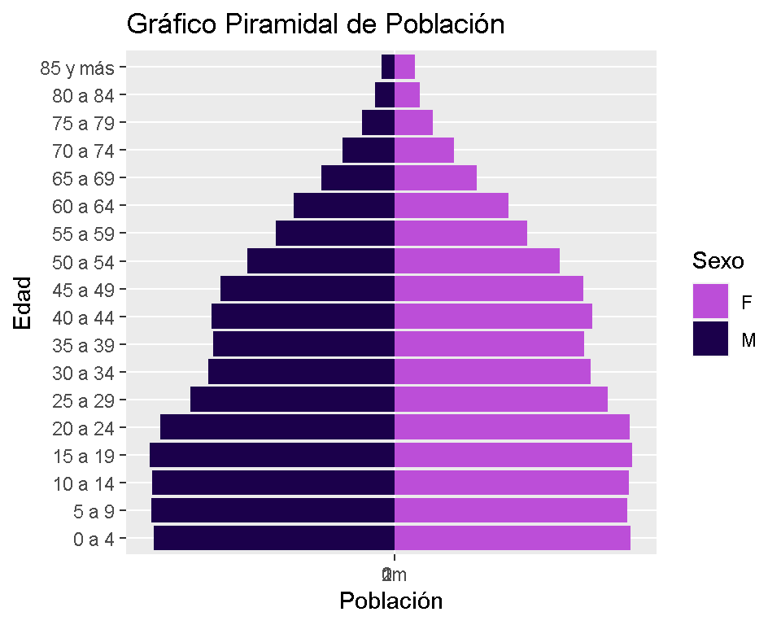

En el siguiente mapa se observa como se distribuye la población sobre la región:

[interactive chart not shown]

### Grupos de población

- Población total respecto al país: 2%. Este valor indica el peso poblacional de la zona metropolitana en relación con la población total de México.
- Población Masculina: 49%
- Población Femenina: 51%
- Relación M-F: 97.558. Este valor indica la proporción de hombres por cada mujer en la zona metropolitana.

### Socioeconómicos

La población en terminos de la poblacioón economicamente activa esta descrita por:

- Porcentaje de población de 12 años y más económicamente activa: 48%
- Porcentaje de población de 12 años y más no económicamente activa: 31% `

### Educación

La educación de la zona metropolitana esta caracterizada por los siguientes estadísticos:

- Porcentaje de población de 15 años y más sin escolaridad:2%
- Porcentaje de población de 15 años y más con al menos un grado aprobado en primaria: 69%
- Porcentaje de población de 15 años y más con educación básica completa: 19%
- Porcentaje de población de 15 años y más con secundaria o equivalente incompleta:2%
- Porcentaje de población de 18 años y más con al menos un grado aprobado en educación media superior: 35%

### Salud

La situación de la afiliación a algún servico de salud es la siguiente:

- Porcentaje de población afiliada a servicios de salud: 78%
- Población sin afiliación a servicios de salud:317997

### Indicadores de desarrollo

Finalmente se presentan tres indicadores de desarrollo; los índices son: índice de Desarrollo Humano (IDH), Índice de Marginación (IM) e Índice de Rezago Social (IRS).

IDH es un indicador elaborado por el Programa de Naciones Unidas para el Desarrollo (PNUD), este busca medir la calidad de vida, así como el progreso socioeconómico de cada entidad y municipio; El cálculo del Índice de Desarrollo Humano se realiza a partir de las tres variables: esperanza de vida, educación e ingreso per cápita.

- Muy Alto - IDH mayor de 1.
- Alto - IDH entre 0.80 a 1.
- Medio - IDH entre 0.50 y 0.80.
- Bajo - IDH entre 0 y 0.50
- Muy Bajo - IDH menores a 0.
- El promedio del IDH en 2020 para la zona metropolitana es de 0.77 según datos del PNUD.

El IM es un índice construido por el consejo Nacional de Población (CONAPO). Este índice considera 4 dimensiones estructurales para su construcción: vivienda, ingreso, educación y distribución de la población. El indice se puede ubicar en 5 estratos designados por la ténica de estratificación de Dalenius-Hodges..

Por último, el IRS es construido por el Consejo Nacional de Evaluación de la Política de Desarrollo Social, CONEVAL, este índice incorpora indicadores de educación, de acceso a servicios de salud, de servicios básicos y tiene como finalidad ordenar los municipios según sus carencias sociales. Este índice, al igual que el IM, se clasifica en cinco estratos.

## Datos económicos.

Con base en la información de los subsectores de los 21 sectores principales de la clasificación del SCIAN, extraída de los Censos Económicos del INEGI durante el periodo de 1998-2018, se ha llevado a cabo la agrupación de los datos de cada municipio que pertenece a una zona metropolitana en cinco grandes sectores: Primarios, Construcción, Manufactura, Comercio y Servicios. Esta clasificación se basa en la metodología proporcionada por el INEGI. Se utilizaron las siguientes variables:

- Unidades económicas (UE) [número de unidades]
- Activiso fijos totales (AF) [miles de pesos a precios corrientes]
- Formación bruta de capital fijo (FB) [miles de pesos a precios corrientes]
- Producción bruta total (PB) [miles de pesos a precios corrientes]
- Personal ocupado total (PO) [número de personas]
- Total de remuneraciones (RE) [miles de pesos a precios corrientes]
- Valor agregado censal bruto (VA) [miles de pesos a precios corrientes]

Posteriormente, se replica la metodología utilizada por García y Carranco (2008) para estimar los coeficientes de participación relativa (PR), de localización de la actividad económica (QL), Hirschman-Herfindahl (HH) e Inverso de Hirschman-Herfindahl (IHH).

$PR_ij$=$X_ij/X_in$

$QL_ij$=$(X_ij⁄X_j )/(X_in⁄X_n)$

$HH_ij$=$X_ij/X_in - X_j/X_n$

$IHH_ij$=$1/(X_ij/X_in - X_j/X_n)$

Donde:

- $X_ij$= Variable económica del sector i en el municipio j
- $X_j$= Variable económica del total de los sectores en el municipio j
- $X_in$= Variable económica del sector i de la Zona Metropolitana del municipio j
- $X_n$= Variable económica del total de los sectores de la Zona Metropolitana del municipio j

### Cifras brutas

#### 1999

##### UE

| Clave | Municipio | Primarios | Construcción | Manufactura | Comercio | Servicios |
| --- | --- | --- | --- | --- | --- | --- |
| 05009 | Francisco I. Madero | 0 | 0 | 95 | 735 | 446 |
| 05017 | Matamoros | 0 | 0 | 154 | 966 | 277 |
| 05035 | Torreón | 12 | 182 | 1,866 | 7,845 | 7,056 |
| 10007 | Gómez Palacio | 13 | 0 | 916 | 3,473 | 2,251 |
| 10012 | Lerdo | 10 | 0 | 219 | 1,049 | 626 |

##### AF

| Clave | Municipio | Primarios | Construcción | Manufactura | Comercio | Servicios |
| --- | --- | --- | --- | --- | --- | --- |
| 05009 | Francisco I. Madero | 7,229 | 0 | 36,384 | 62,740 | 125,751 |
| 05017 | Matamoros | 3,315 | 0 | 111,324 | 50,919 | 79,497 |
| 05035 | Torreón | 1,070,529 | 327,915 | 9,854,601 | 1,719,586 | 2,625,274 |
| 10007 | Gómez Palacio | 32,282 | 75,965 | 4,031,366 | 744,458 | 2,295,666 |
| 10012 | Lerdo | 24,027 | 1,092 | 332,713 | 57,529 | 177,084 |

##### FB

| Clave | Municipio | Primarios | Construcción | Manufactura | Comercio | Servicios |
| --- | --- | --- | --- | --- | --- | --- |
| 05009 | Francisco I. Madero | 0 | 0 | 7,737 | 5,939 | 418 |
| 05017 | Matamoros | 0 | 0 | 5,669 | 1,255 | 6,234 |
| 05035 | Torreón | 183,319 | 39,276 | 773,658 | 109,888 | 179,711 |
| 10007 | Gómez Palacio | 641 | 18,306 | 337,478 | 51,594 | 277,470 |
| 10012 | Lerdo | 4,703 | 0 | 53,384 | 2,411 | 18,036 |

##### PB

| Clave | Municipio | Primarios | Construcción | Manufactura | Comercio | Servicios |
| --- | --- | --- | --- | --- | --- | --- |
| 05009 | Francisco I. Madero | 8,833 | 0 | 105,654 | 139,729 | 44,441 |
| 05017 | Matamoros | 11,627 | 0 | 96,919 | 108,499 | 61,516 |
| 05035 | Torreón | 1,034,899 | 883,083 | 17,922,706 | 4,477,168 | 5,884,786 |
| 10007 | Gómez Palacio | 72,562 | 375,136 | 13,080,544 | 1,545,887 | 2,226,646 |
| 10012 | Lerdo | 25,869 | 1,371 | 790,659 | 175,843 | 340,571 |

##### PO

| Clave | Municipio | Primarios | Construcción | Manufactura | Comercio | Servicios |
| --- | --- | --- | --- | --- | --- | --- |
| 05009 | Francisco I. Madero | 117 | 0 | 1,201 | 1,678 | 948 |
| 05017 | Matamoros | 116 | 0 | 1,726 | 1,754 | 969 |
| 05035 | Torreón | 1,545 | 9,055 | 39,933 | 31,478 | 38,427 |
| 10007 | Gómez Palacio | 936 | 2,622 | 28,977 | 11,147 | 24,449 |
| 10012 | Lerdo | 303 | 16 | 8,493 | 2,233 | 3,348 |

##### RE

| Clave | Municipio | Primarios | Construcción | Manufactura | Comercio | Servicios |
| --- | --- | --- | --- | --- | --- | --- |
| 05009 | Francisco I. Madero | 2,427 | 0 | 24,378 | 17,201 | 6,600 |
| 05017 | Matamoros | 2,670 | 0 | 32,211 | 13,285 | 7,942 |
| 05035 | Torreón | 108,086 | 130,145 | 1,408,186 | 706,666 | 1,242,071 |
| 10007 | Gómez Palacio | 26,245 | 51,792 | 830,574 | 226,409 | 726,648 |
| 10012 | Lerdo | 4,669 | 209 | 202,029 | 18,568 | 45,407 |

##### VA

| Clave | Municipio | Primarios | Construcción | Manufactura | Comercio | Servicios |
| --- | --- | --- | --- | --- | --- | --- |
| 05009 | Francisco I. Madero | 4,902 | 0 | 40,878 | 110,463 | 22,364 |
| 05017 | Matamoros | 5,104 | 0 | 41,922 | 82,562 | 27,725 |
| 05035 | Torreón | 445,342 | 241,230 | 4,669,218 | 3,055,350 | 3,085,935 |
| 10007 | Gómez Palacio | 38,961 | 123,152 | 4,022,346 | 1,044,458 | 1,239,337 |
| 10012 | Lerdo | 12,746 | 462 | 497,611 | 93,595 | 198,638 |

#### 2004

##### UE

| Clave | Municipio | Primarios | Construcción | Manufactura | Comercio | Servicios |
| --- | --- | --- | --- | --- | --- | --- |
| 05009 | Francisco I. Madero | 0 | 0 | 91 | 715 | 417 |
| 05017 | Matamoros | 0 | 0 | 155 | 1,107 | 431 |
| 05035 | Torreón | 0 | 234 | 1,711 | 8,445 | 7,461 |
| 10007 | Gómez Palacio | 6 | 0 | 795 | 3,793 | 2,741 |
| 10012 | Lerdo | 0 | 0 | 217 | 1,178 | 714 |

##### AF

| Clave | Municipio | Primarios | Construcción | Manufactura | Comercio | Servicios |
| --- | --- | --- | --- | --- | --- | --- |
| 05009 | Francisco I. Madero | 0 | 20 | 93,425 | 128,895 | 82,115 |
| 05017 | Matamoros | 18,916 | 685 | 56,231 | 98,060 | 161,365 |
| 05035 | Torreón | 393,086 | 652,309 | 18,128,851 | 3,695,294 | 5,745,948 |
| 10007 | Gómez Palacio | 27,754 | 212,619 | 8,143,786 | 1,222,142 | 10,958,982 |
| 10012 | Lerdo | 73,174 | 2,625 | 539,278 | 109,522 | 361,194 |

##### FB

| Clave | Municipio | Primarios | Construcción | Manufactura | Comercio | Servicios |
| --- | --- | --- | --- | --- | --- | --- |
| 05009 | Francisco I. Madero | 0 | 0 | 2,073 | 6,612 | 4,092 |
| 05017 | Matamoros | 0 | 380 | 1,849 | 4,846 | 6,667 |
| 05035 | Torreón | 4,881 | 65,410 | 741,779 | 245,076 | 412,217 |
| 10007 | Gómez Palacio | 185 | 32,905 | 538,733 | 109,791 | 1,792,964 |
| 10012 | Lerdo | 0 | 867 | 88,161 | 6,140 | 2,898 |

##### PB

| Clave | Municipio | Primarios | Construcción | Manufactura | Comercio | Servicios |
| --- | --- | --- | --- | --- | --- | --- |
| 05009 | Francisco I. Madero | 0 | 78 | 221,979 | 332,382 | 118,650 |
| 05017 | Matamoros | 82,702 | 1,560 | 174,537 | 209,893 | 182,403 |
| 05035 | Torreón | 107,525 | 2,127,274 | 32,626,794 | 8,386,178 | 13,097,473 |
| 10007 | Gómez Palacio | 47,422 | 898,476 | 20,331,115 | 3,014,887 | 9,742,541 |
| 10012 | Lerdo | 41,430 | 9,657 | 1,992,483 | 180,501 | 402,487 |

##### PO

| Clave | Municipio | Primarios | Construcción | Manufactura | Comercio | Servicios |
| --- | --- | --- | --- | --- | --- | --- |
| 05009 | Francisco I. Madero | 0 | 1 | 2,186 | 2,264 | 1,134 |
| 05017 | Matamoros | 68 | 6 | 1,660 | 2,651 | 1,382 |
| 05035 | Torreón | 797 | 10,249 | 56,189 | 45,481 | 52,746 |
| 10007 | Gómez Palacio | 148 | 2,249 | 33,458 | 16,800 | 26,542 |
| 10012 | Lerdo | 165 | 57 | 10,200 | 2,589 | 2,866 |

##### RE

| Clave | Municipio | Primarios | Construcción | Manufactura | Comercio | Servicios |
| --- | --- | --- | --- | --- | --- | --- |
| 05009 | Francisco I. Madero | 0 | 0 | 110,463 | 50,909 | 17,900 |
| 05017 | Matamoros | 5,821 | 419 | 62,017 | 27,042 | 22,324 |
| 05035 | Torreón | 126,694 | 313,772 | 2,912,414 | 1,476,739 | 2,473,143 |
| 10007 | Gómez Palacio | 1,849 | 77,756 | 1,347,404 | 497,656 | 1,771,748 |
| 10012 | Lerdo | 6,423 | 1,983 | 437,470 | 27,225 | 68,559 |

##### VA

| Clave | Municipio | Primarios | Construcción | Manufactura | Comercio | Servicios |
| --- | --- | --- | --- | --- | --- | --- |
| 05009 | Francisco I. Madero | 0 | 33 | 137,097 | 273,587 | 62,810 |
| 05017 | Matamoros | 73,753 | 496 | 106,284 | 174,006 | 80,920 |
| 05035 | Torreón | -713 | 829,462 | 11,185,216 | 5,659,105 | 6,478,030 |
| 10007 | Gómez Palacio | 28,477 | 300,042 | 4,943,560 | 1,996,069 | 4,723,240 |
| 10012 | Lerdo | 30,543 | 4,654 | 1,044,616 | 143,504 | 233,385 |

#### 2009

##### UE

| Clave | Municipio | Primarios | Construcción | Manufactura | Comercio | Servicios |
| --- | --- | --- | --- | --- | --- | --- |
| 05009 | Francisco I. Madero | 0 | 0 | 96 | 776 | 509 |
| 05017 | Matamoros | 0 | 0 | 237 | 1,149 | 557 |
| 05035 | Torreón | 0 | 247 | 1,928 | 9,571 | 9,083 |
| 10007 | Gómez Palacio | 0 | 0 | 899 | 4,190 | 3,461 |
| 10012 | Lerdo | 0 | 0 | 249 | 1,421 | 949 |

##### AF

| Clave | Municipio | Primarios | Construcción | Manufactura | Comercio | Servicios |
| --- | --- | --- | --- | --- | --- | --- |
| 05009 | Francisco I. Madero | 36,060 | 0 | 39,236 | 177,660 | 97,831 |
| 05017 | Matamoros | 8,076 | 2 | 229,056 | 215,472 | 236,136 |
| 05035 | Torreón | 3,081,783 | 3,272,568 | 28,696,088 | 6,209,666 | 10,744,070 |
| 10007 | Gómez Palacio | 41,203 | 280,089 | 7,324,555 | 2,346,819 | 24,283,971 |
| 10012 | Lerdo | 39,199 | 8,057 | 212,773 | 245,161 | 625,530 |

##### FB

| Clave | Municipio | Primarios | Construcción | Manufactura | Comercio | Servicios |
| --- | --- | --- | --- | --- | --- | --- |
| 05009 | Francisco I. Madero | 0 | 0 | 2,056 | 10,066 | 8,264 |
| 05017 | Matamoros | 90 | 0 | 10,342 | 12,803 | 1,376 |
| 05035 | Torreón | 329,204 | 432,055 | 1,410,867 | 413,600 | 547,596 |
| 10007 | Gómez Palacio | 813 | 40,284 | 493,427 | 179,215 | 847,768 |
| 10012 | Lerdo | 8,615 | 164 | 11,327 | 7,170 | 29,848 |

##### PB

| Clave | Municipio | Primarios | Construcción | Manufactura | Comercio | Servicios |
| --- | --- | --- | --- | --- | --- | --- |
| 05009 | Francisco I. Madero | 6,048 | 0 | 97,334 | 288,557 | 147,965 |
| 05017 | Matamoros | 95,409 | 0 | 942,653 | 281,563 | 285,546 |
| 05035 | Torreón | 1,726,419 | 4,389,257 | 92,781,887 | 9,090,705 | 13,992,273 |
| 10007 | Gómez Palacio | 78,311 | 1,116,642 | 30,205,531 | 4,958,925 | 13,786,380 |
| 10012 | Lerdo | 65,638 | 33,792 | 1,234,562 | 336,944 | 617,508 |

##### PO

| Clave | Municipio | Primarios | Construcción | Manufactura | Comercio | Servicios |
| --- | --- | --- | --- | --- | --- | --- |
| 05009 | Francisco I. Madero | 69 | 0 | 1,056 | 2,446 | 1,536 |
| 05017 | Matamoros | 63 | 3 | 3,986 | 3,294 | 2,251 |
| 05035 | Torreón | 3,009 | 9,839 | 44,761 | 48,167 | 68,408 |
| 10007 | Gómez Palacio | 219 | 2,182 | 24,423 | 21,010 | 28,256 |
| 10012 | Lerdo | 256 | 64 | 4,734 | 3,908 | 3,616 |

##### RE

| Clave | Municipio | Primarios | Construcción | Manufactura | Comercio | Servicios |
| --- | --- | --- | --- | --- | --- | --- |
| 05009 | Francisco I. Madero | 1,036 | 0 | 40,820 | 36,065 | 23,354 |
| 05017 | Matamoros | 14,088 | 0 | 141,094 | 61,709 | 53,463 |
| 05035 | Torreón | 153,316 | 540,285 | 3,031,909 | 1,435,200 | 3,793,581 |
| 10007 | Gómez Palacio | 2,958 | 90,558 | 1,366,018 | 783,330 | 2,407,332 |
| 10012 | Lerdo | 12,008 | 3,830 | 257,380 | 63,161 | 97,196 |

##### VA

| Clave | Municipio | Primarios | Construcción | Manufactura | Comercio | Servicios |
| --- | --- | --- | --- | --- | --- | --- |
| 05009 | Francisco I. Madero | 5,046 | 0 | 59,415 | 185,181 | 90,260 |
| 05017 | Matamoros | 6,870 | -11 | 425,567 | 183,731 | 147,978 |
| 05035 | Torreón | 631,748 | 1,196,460 | 24,440,187 | 4,878,514 | 7,828,013 |
| 10007 | Gómez Palacio | 43,206 | 327,783 | 8,438,218 | 2,400,740 | 6,939,369 |
| 10012 | Lerdo | 51,199 | 6,379 | 638,694 | 188,337 | 348,873 |

#### 2014

##### UE

| Clave | Municipio | Primarios | Construcción | Manufactura | Comercio | Servicios |
| --- | --- | --- | --- | --- | --- | --- |
| 05009 | Francisco I. Madero | 0 | 0 | 109 | 897 | 622 |
| 05017 | Matamoros | 3 | 0 | 203 | 1,269 | 845 |
| 05035 | Torreón | 14 | 187 | 1,785 | 9,865 | 10,750 |
| 10007 | Gómez Palacio | 8 | 58 | 852 | 4,283 | 4,126 |
| 10012 | Lerdo | 5 | 0 | 264 | 1,477 | 1,180 |

##### AF

| Clave | Municipio | Primarios | Construcción | Manufactura | Comercio | Servicios |
| --- | --- | --- | --- | --- | --- | --- |
| 05009 | Francisco I. Madero | 0 | 0 | 71,976 | 236,763 | 139,325 |
| 05017 | Matamoros | 57,972 | 0 | 203,450 | 232,787 | 110,950 |
| 05035 | Torreón | 4,753,193 | 1,988,018 | 27,389,263 | 8,448,324 | 10,969,676 |
| 10007 | Gómez Palacio | 209,700 | 298,996 | 9,333,050 | 3,370,986 | 3,120,869 |
| 10012 | Lerdo | 218,579 | 0 | 679,749 | 285,128 | 333,555 |

##### FB

| Clave | Municipio | Primarios | Construcción | Manufactura | Comercio | Servicios |
| --- | --- | --- | --- | --- | --- | --- |
| 05009 | Francisco I. Madero | 0 | 0 | 538 | 16,271 | 197 |
| 05017 | Matamoros | 0 | 0 | 4,845 | 6,259 | 2,908 |
| 05035 | Torreón | -22,620 | 273,845 | 2,333,076 | 476,435 | 787,535 |
| 10007 | Gómez Palacio | 3,720 | 18,634 | 318,095 | 122,382 | 257,111 |
| 10012 | Lerdo | 18,378 | 0 | 6,417 | 20,379 | -16,150 |

##### PB

| Clave | Municipio | Primarios | Construcción | Manufactura | Comercio | Servicios |
| --- | --- | --- | --- | --- | --- | --- |
| 05009 | Francisco I. Madero | 0 | 0 | 731,002 | 523,509 | 182,897 |
| 05017 | Matamoros | 37,564 | 0 | 590,856 | 344,499 | 190,889 |
| 05035 | Torreón | 2,341,119 | 3,537,340 | 113,928,075 | 13,733,492 | 17,599,303 |
| 10007 | Gómez Palacio | 282,370 | 1,084,290 | 36,647,942 | 5,887,078 | 5,668,376 |
| 10012 | Lerdo | 90,870 | 0 | 2,004,486 | 465,470 | 503,530 |

##### PO

| Clave | Municipio | Primarios | Construcción | Manufactura | Comercio | Servicios |
| --- | --- | --- | --- | --- | --- | --- |
| 05009 | Francisco I. Madero | 0 | 0 | 3,298 | 2,822 | 1,492 |
| 05017 | Matamoros | 58 | 0 | 3,227 | 3,183 | 2,149 |
| 05035 | Torreón | 1,240 | 5,234 | 46,642 | 50,047 | 81,897 |
| 10007 | Gómez Palacio | 379 | 1,495 | 24,223 | 21,571 | 25,252 |
| 10012 | Lerdo | 162 | 0 | 7,736 | 4,233 | 3,972 |

##### RE

| Clave | Municipio | Primarios | Construcción | Manufactura | Comercio | Servicios |
| --- | --- | --- | --- | --- | --- | --- |
| 05009 | Francisco I. Madero | 0 | 0 | 391,065 | 82,990 | 29,127 |
| 05017 | Matamoros | 4,916 | 0 | 193,023 | 38,084 | 24,030 |
| 05035 | Torreón | 63,399 | 278,942 | 3,998,376 | 1,775,747 | 5,320,247 |
| 10007 | Gómez Palacio | 12,335 | 87,489 | 1,713,363 | 952,540 | 1,195,741 |
| 10012 | Lerdo | 16,796 | 0 | 631,036 | 75,916 | 122,082 |

##### VA

| Clave | Municipio | Primarios | Construcción | Manufactura | Comercio | Servicios |
| --- | --- | --- | --- | --- | --- | --- |
| 05009 | Francisco I. Madero | 0 | 0 | 564,485 | 381,961 | 102,705 |
| 05017 | Matamoros | 19,162 | 0 | 325,924 | 237,289 | 83,210 |
| 05035 | Torreón | 1,369,353 | 1,199,980 | 29,220,006 | 8,339,935 | 9,009,996 |
| 10007 | Gómez Palacio | 58,769 | 199,712 | 8,233,110 | 3,361,111 | 2,524,969 |
| 10012 | Lerdo | 47,868 | 0 | 1,301,365 | 275,422 | 290,376 |

#### 2019

##### UE

| Clave | Municipio | Primarios | Construcción | Manufactura | Comercio | Servicios |
| --- | --- | --- | --- | --- | --- | --- |
| 05009 | Francisco I. Madero | 1 | 3 | 118 | 918 | 686 |
| 05017 | Matamoros | 6 | 4 | 276 | 1,397 | 1,020 |
| 05035 | Torreón | 27 | 255 | 2,046 | 10,696 | 12,549 |
| 10007 | Gómez Palacio | 9 | 82 | 972 | 4,623 | 4,897 |
| 10012 | Lerdo | 7 | 10 | 321 | 1,665 | 1,534 |

##### AF

| Clave | Municipio | Primarios | Construcción | Manufactura | Comercio | Servicios |
| --- | --- | --- | --- | --- | --- | --- |
| 05009 | Francisco I. Madero | 0 | 0 | 186,095 | 448,350 | 255,762 |
| 05017 | Matamoros | 48,658 | 0 | 683,139 | 700,811 | 370,718 |
| 05035 | Torreón | 11,834 | 2,559,257 | 33,536,377 | 13,821,351 | 13,994,835 |
| 10007 | Gómez Palacio | 353,698 | 537,904 | 10,446,682 | 12,628,524 | 4,749,309 |
| 10012 | Lerdo | 83,395 | 4,671 | 997,156 | 860,025 | 1,347,876 |

##### FB

| Clave | Municipio | Primarios | Construcción | Manufactura | Comercio | Servicios |
| --- | --- | --- | --- | --- | --- | --- |
| 05009 | Francisco I. Madero | 0 | 0 | 4,269 | 14,278 | 9,533 |
| 05017 | Matamoros | 0 | 0 | 25,367 | 11,533 | 17,358 |
| 05035 | Torreón | 16 | 126,210 | 2,081,153 | 540,638 | 959,209 |
| 10007 | Gómez Palacio | 3,278 | 13,830 | 734,556 | 7,346,982 | 169,400 |
| 10012 | Lerdo | -973 | 0 | 19,066 | 26,753 | 39,780 |

##### PB

| Clave | Municipio | Primarios | Construcción | Manufactura | Comercio | Servicios |
| --- | --- | --- | --- | --- | --- | --- |
| 05009 | Francisco I. Madero | 0 | 0 | 901,444 | 919,434 | 271,502 |
| 05017 | Matamoros | 57,432 | 0 | 2,585,060 | 839,784 | 548,085 |
| 05035 | Torreón | 56,777 | 8,365,438 | 183,597,663 | 25,427,426 | 30,188,120 |
| 10007 | Gómez Palacio | 351,709 | 2,978,460 | 54,667,334 | 12,341,601 | 10,417,254 |
| 10012 | Lerdo | 80,093 | 4,356 | 2,214,394 | 1,398,308 | 1,064,278 |

##### PO

| Clave | Municipio | Primarios | Construcción | Manufactura | Comercio | Servicios |
| --- | --- | --- | --- | --- | --- | --- |
| 05009 | Francisco I. Madero | 0 | 0 | 3,792 | 3,086 | 1,825 |
| 05017 | Matamoros | 144 | 0 | 4,402 | 3,556 | 3,045 |
| 05035 | Torreón | 153 | 9,625 | 70,435 | 54,731 | 104,247 |
| 10007 | Gómez Palacio | 441 | 2,797 | 32,191 | 21,661 | 37,092 |
| 10012 | Lerdo | 158 | 20 | 6,488 | 4,642 | 5,348 |

##### RE

| Clave | Municipio | Primarios | Construcción | Manufactura | Comercio | Servicios |
| --- | --- | --- | --- | --- | --- | --- |
| 05009 | Francisco I. Madero | 0 | 0 | 314,207 | 131,590 | 40,473 |
| 05017 | Matamoros | 16,782 | 0 | 382,140 | 84,667 | 88,470 |
| 05035 | Torreón | 3,600 | 588,170 | 5,672,684 | 2,426,414 | 6,675,284 |
| 10007 | Gómez Palacio | 17,420 | 110,632 | 2,768,799 | 1,208,362 | 2,522,152 |
| 10012 | Lerdo | 15,107 | 698 | 430,683 | 108,183 | 240,283 |

##### VA

| Clave | Municipio | Primarios | Construcción | Manufactura | Comercio | Servicios |
| --- | --- | --- | --- | --- | --- | --- |
| 05009 | Francisco I. Madero | 0 | 0 | 595,090 | 657,632 | 127,660 |
| 05017 | Matamoros | 20,640 | 0 | 714,210 | 671,985 | 273,307 |
| 05035 | Torreón | 20,226 | 2,667,772 | 72,264,280 | 17,099,018 | 16,368,514 |
| 10007 | Gómez Palacio | 134,437 | 817,355 | 16,292,165 | 7,992,544 | 5,688,351 |
| 10012 | Lerdo | 49,038 | 2,479 | 1,114,567 | 1,055,735 | 522,454 |

### Coeficientes de localización (QL)

#### 1999

##### UE

| Clave | Municipio | Primarios | Construcción | Manufactura | Comercio | Servicios |
| --- | --- | --- | --- | --- | --- | --- |
| 05009 | Francisco I. Madero | 0.0000 | 0.0000 | 0.6710 | 1.0917 | 0.9907 |
| 05017 | Matamoros | 0.0000 | 0.0000 | 0.9935 | 1.3106 | 0.5620 |
| 05035 | Torreón | 0.2664 | 1.8044 | 0.9915 | 0.8766 | 1.1791 |
| 10007 | Gómez Palacio | 0.7357 | 0.0000 | 1.2409 | 0.9894 | 0.9590 |
| 10012 | Lerdo | 1.9775 | 0.0000 | 1.0366 | 1.0442 | 0.9319 |

##### AF

| Clave | Municipio | Primarios | Construcción | Manufactura | Comercio | Servicios |
| --- | --- | --- | --- | --- | --- | --- |
| 05009 | Francisco I. Madero | 1.2797 | 0.0000 | 0.4607 | 3.5591 | 0.9955 |
| 05017 | Matamoros | 0.5558 | 0.0000 | 1.3352 | 2.7358 | 0.5961 |
| 05035 | Torreón | 2.8200 | 1.3808 | 1.8569 | 1.4516 | 0.3093 |
| 10007 | Gómez Palacio | 0.1847 | 0.6949 | 1.6502 | 1.3652 | 0.5875 |
| 10012 | Lerdo | 1.6664 | 0.1211 | 1.6505 | 1.2785 | 0.5492 |

##### FB

[output not shown]

##### PB

| Clave | Municipio | Primarios | Construcción | Manufactura | Comercio | Servicios |
| --- | --- | --- | --- | --- | --- | --- |
| 05009 | Francisco I. Madero | 2.9638 | 0.0000 | 0.7149 | 3.3482 | 0.4659 |
| 05017 | Matamoros | 4.1827 | 0.0000 | 0.7031 | 2.7874 | 0.6914 |
| 05035 | Torreón | 3.4337 | 0.8103 | 1.1993 | 1.0609 | 0.6101 |
| 10007 | Gómez Palacio | 0.4203 | 0.6009 | 1.5280 | 0.6395 | 0.4030 |
| 10012 | Lerdo | 1.9428 | 0.0285 | 1.1975 | 0.9431 | 0.7992 |

##### PO

| Clave | Municipio | Primarios | Construcción | Manufactura | Comercio | Servicios |
| --- | --- | --- | --- | --- | --- | --- |
| 05009 | Francisco I. Madero | 3.3443 | 0.0000 | 0.9865 | 1.6397 | 0.6509 |
| 05017 | Matamoros | 2.8647 | 0.0000 | 1.2248 | 1.4808 | 0.5748 |
| 05035 | Torreón | 1.4462 | 1.4001 | 1.0741 | 1.0073 | 0.8640 |
| 10007 | Gómez Palacio | 1.5488 | 0.7167 | 1.3778 | 0.6306 | 0.9718 |
| 10012 | Lerdo | 2.3733 | 0.0207 | 1.9116 | 0.5979 | 0.6299 |

##### RE

| Clave | Municipio | Primarios | Construcción | Manufactura | Comercio | Servicios |
| --- | --- | --- | --- | --- | --- | --- |
| 05009 | Francisco I. Madero | 4.2291 | 0.0000 | 1.3029 | 2.3936 | 0.2890 |
| 05017 | Matamoros | 4.1963 | 0.0000 | 1.5527 | 1.6674 | 0.3137 |
| 05035 | Torreón | 2.6511 | 1.4086 | 1.0594 | 1.3842 | 0.7657 |
| 10007 | Gómez Palacio | 1.2431 | 1.0826 | 1.2066 | 0.8564 | 0.8650 |
| 10012 | Lerdo | 1.5199 | 0.0300 | 2.0171 | 0.4827 | 0.3715 |

##### VA

| Clave | Municipio | Primarios | Construcción | Manufactura | Comercio | Servicios |
| --- | --- | --- | --- | --- | --- | --- |
| 05009 | Francisco I. Madero | 2.3343 | 0.0000 | 0.6212 | 2.7766 | 0.3341 |
| 05017 | Matamoros | 2.7595 | 0.0000 | 0.7233 | 2.3562 | 0.4702 |
| 05035 | Torreón | 3.2945 | 0.9438 | 1.1022 | 1.1931 | 0.7161 |
| 10007 | Gómez Palacio | 0.5123 | 0.8564 | 1.6878 | 0.7249 | 0.5112 |
| 10012 | Lerdo | 1.3499 | 0.0259 | 1.6818 | 0.5232 | 0.6599 |

#### 2004

##### UE

| Clave | Municipio | Primarios | Construcción | Manufactura | Comercio | Servicios |
| --- | --- | --- | --- | --- | --- | --- |
| 05009 | Francisco I. Madero | 0.0000 | 0.0000 | 0.7612 | 1.0828 | 0.9589 |
| 05017 | Matamoros | 0.0000 | 0.0000 | 0.9367 | 1.2110 | 0.7160 |
| 05035 | Torreón | 0.0000 | 2.6490 | 0.9806 | 0.8762 | 1.1755 |
| 10007 | Gómez Palacio | 0.4542 | 0.0000 | 1.1088 | 0.9577 | 1.0510 |
| 10012 | Lerdo | 0.0000 | 0.0000 | 1.0527 | 1.0345 | 0.9521 |

##### AF

| Clave | Municipio | Primarios | Construcción | Manufactura | Comercio | Servicios |
| --- | --- | --- | --- | --- | --- | --- |
| 05009 | Francisco I. Madero | 0.0000 | 0.0060 | 0.8376 | 4.7074 | 0.5226 |
| 05017 | Matamoros | 3.3926 | 0.1860 | 0.4578 | 3.2522 | 0.9326 |
| 05035 | Torreón | 0.8260 | 2.0748 | 1.7293 | 1.4359 | 0.3891 |
| 10007 | Gómez Palacio | 0.0811 | 0.9410 | 1.0809 | 0.6608 | 1.0325 |
| 10012 | Lerdo | 4.0522 | 0.2200 | 1.3557 | 1.1216 | 0.6446 |

##### FB

[output not shown]

##### PB

| Clave | Municipio | Primarios | Construcción | Manufactura | Comercio | Servicios |
| --- | --- | --- | --- | --- | --- | --- |
| 05009 | Francisco I. Madero | 0.0000 | 0.0037 | 0.7140 | 3.5951 | 0.4912 |
| 05017 | Matamoros | 12.4302 | 0.0757 | 0.5804 | 2.3470 | 0.7806 |
| 05035 | Torreón | 0.1867 | 1.1928 | 1.2537 | 1.0836 | 0.6477 |
| 10007 | Gómez Palacio | 0.1364 | 0.8340 | 1.2933 | 0.6449 | 0.7976 |
| 10012 | Lerdo | 1.5436 | 0.1162 | 1.6424 | 0.5003 | 0.4270 |

##### PO

| Clave | Municipio | Primarios | Construcción | Manufactura | Comercio | Servicios |
| --- | --- | --- | --- | --- | --- | --- |
| 05009 | Francisco I. Madero | 0.0000 | 0.0039 | 1.4855 | 1.3865 | 0.5211 |
| 05017 | Matamoros | 1.4265 | 0.0225 | 1.0925 | 1.5723 | 0.6150 |
| 05035 | Torreón | 0.5827 | 1.3391 | 1.2889 | 0.9402 | 0.8181 |
| 10007 | Gómez Palacio | 0.2261 | 0.6139 | 1.6034 | 0.7256 | 0.8601 |
| 10012 | Lerdo | 1.2573 | 0.0776 | 2.4383 | 0.5578 | 0.4633 |

##### RE

| Clave | Municipio | Primarios | Construcción | Manufactura | Comercio | Servicios |
| --- | --- | --- | --- | --- | --- | --- |
| 05009 | Francisco I. Madero | 0.0000 | 0.0000 | 1.7569 | 1.8164 | 0.2183 |
| 05017 | Matamoros | 5.1984 | 0.1364 | 1.5034 | 1.4705 | 0.4150 |
| 05035 | Torreón | 1.8224 | 1.6454 | 1.1371 | 1.2934 | 0.7405 |
| 10007 | Gómez Palacio | 0.0525 | 0.8056 | 1.0394 | 0.8612 | 1.0481 |
| 10012 | Lerdo | 1.2456 | 0.1402 | 2.3029 | 0.3215 | 0.2768 |

##### VA

| Clave | Municipio | Primarios | Construcción | Manufactura | Comercio | Servicios |
| --- | --- | --- | --- | --- | --- | --- |
| 05009 | Francisco I. Madero | 0.0000 | 0.0031 | 0.8908 | 2.9328 | 0.3018 |
| 05017 | Matamoros | 10.5119 | 0.0510 | 0.7509 | 2.0284 | 0.4228 |
| 05035 | Torreón | -0.0018 | 1.5369 | 1.4249 | 1.1894 | 0.6103 |
| 10007 | Gómez Palacio | 0.1474 | 1.1197 | 1.2684 | 0.8450 | 0.8962 |
| 10012 | Lerdo | 1.3013 | 0.1430 | 2.2063 | 0.5001 | 0.3645 |

#### 2009

##### UE

| Clave | Municipio | Primarios | Construcción | Manufactura | Comercio | Servicios |
| --- | --- | --- | --- | --- | --- | --- |
| 05009 | Francisco I. Madero | 0.0000 | 0.0000 | 0.6749 | 1.1051 | 0.9671 |
| 05017 | Matamoros | 0.0000 | 0.0000 | 1.1843 | 1.1630 | 0.7522 |
| 05035 | Torreón | 0.0000 | 1.9926 | 0.8987 | 0.9037 | 1.1442 |
| 10007 | Gómez Palacio | 0.0000 | 0.0000 | 1.0209 | 0.9638 | 1.0621 |
| 10012 | Lerdo | 0.0000 | 0.0000 | 0.9231 | 1.0671 | 0.9508 |

##### AF

| Clave | Municipio | Primarios | Construcción | Manufactura | Comercio | Servicios |
| --- | --- | --- | --- | --- | --- | --- |
| 05009 | Francisco I. Madero | 5.4234 | 0.0000 | 0.4182 | 5.3858 | 0.4620 |
| 05017 | Matamoros | 0.6186 | 0.0002 | 1.2434 | 3.3269 | 0.5679 |
| 05035 | Torreón | 3.1265 | 3.9629 | 2.0631 | 1.2698 | 0.3422 |
| 10007 | Gómez Palacio | 0.0634 | 0.5146 | 0.7990 | 0.7281 | 1.1736 |
| 10012 | Lerdo | 1.8290 | 0.4487 | 0.7036 | 2.3057 | 0.9164 |

##### FB

[output not shown]

##### PB

| Clave | Municipio | Primarios | Construcción | Manufactura | Comercio | Servicios |
| --- | --- | --- | --- | --- | --- | --- |
| 05009 | Francisco I. Madero | 0.6185 | 0.0000 | 0.3715 | 5.1085 | 0.7837 |
| 05017 | Matamoros | 3.2821 | 0.0000 | 1.2101 | 1.6766 | 0.5087 |
| 05035 | Torreón | 0.7815 | 0.8512 | 1.5673 | 0.7123 | 0.3280 |
| 10007 | Gómez Palacio | 0.0862 | 0.5267 | 1.2412 | 0.9452 | 0.7862 |
| 10012 | Lerdo | 1.5838 | 0.3493 | 1.1116 | 1.4073 | 0.7716 |

##### PO

| Clave | Municipio | Primarios | Construcción | Manufactura | Comercio | Servicios |
| --- | --- | --- | --- | --- | --- | --- |
| 05009 | Francisco I. Madero | 1.8925 | 0.0000 | 0.8697 | 1.6845 | 0.6978 |
| 05017 | Matamoros | 0.9195 | 0.0079 | 1.7469 | 1.2072 | 0.5442 |
| 05035 | Torreón | 2.4198 | 1.4213 | 1.0808 | 0.9726 | 0.9111 |
| 10007 | Gómez Palacio | 0.4032 | 0.7215 | 1.3500 | 0.9711 | 0.8615 |
| 10012 | Lerdo | 2.8509 | 0.1280 | 1.5830 | 1.0928 | 0.6670 |

##### RE

| Clave | Municipio | Primarios | Construcción | Manufactura | Comercio | Servicios |
| --- | --- | --- | --- | --- | --- | --- |
| 05009 | Francisco I. Madero | 0.7550 | 0.0000 | 1.2225 | 2.7936 | 0.4689 |
| 05017 | Matamoros | 3.8457 | 0.0000 | 1.5830 | 1.7906 | 0.4021 |
| 05035 | Torreón | 1.2636 | 1.6112 | 1.0270 | 1.2574 | 0.8614 |
| 10007 | Gómez Palacio | 0.0469 | 0.5200 | 0.8910 | 1.3215 | 1.0525 |
| 10012 | Lerdo | 2.0439 | 0.2359 | 1.8006 | 1.1428 | 0.4558 |

##### VA

| Clave | Municipio | Primarios | Construcción | Manufactura | Comercio | Servicios |
| --- | --- | --- | --- | --- | --- | --- |
| 05009 | Francisco I. Madero | 0.5232 | 0.0000 | 0.4932 | 3.7771 | 0.5989 |
| 05017 | Matamoros | 0.3169 | -0.0005 | 1.5714 | 1.6670 | 0.4368 |
| 05035 | Torreón | 0.5713 | 1.0370 | 1.7693 | 0.8678 | 0.4530 |
| 10007 | Gómez Palacio | 0.0839 | 0.6101 | 1.3118 | 0.9171 | 0.8624 |
| 10012 | Lerdo | 1.4629 | 0.1747 | 1.4610 | 1.0586 | 0.6379 |

#### 2014

##### UE

| Clave | Municipio | Primarios | Construcción | Manufactura | Comercio | Servicios |
| --- | --- | --- | --- | --- | --- | --- |
| 05009 | Francisco I. Madero | 0.0000 | 0.0000 | 0.6817 | 1.1288 | 0.9388 |
| 05017 | Matamoros | 0.7653 | 0.0000 | 0.8909 | 1.1206 | 0.8949 |
| 05035 | Torreón | 0.3666 | 1.6579 | 0.8042 | 0.8942 | 1.1687 |
| 10007 | Gómez Palacio | 0.5076 | 1.2460 | 0.9301 | 0.9408 | 1.0869 |
| 10012 | Lerdo | 1.0113 | 0.0000 | 0.9187 | 1.0341 | 0.9909 |

##### AF

| Clave | Municipio | Primarios | Construcción | Manufactura | Comercio | Servicios |
| --- | --- | --- | --- | --- | --- | --- |
| 05009 | Francisco I. Madero | 0.0000 | 0.0000 | 0.5875 | 4.8071 | 0.5266 |
| 05017 | Matamoros | 7.3098 | 0.0000 | 1.2296 | 3.4994 | 0.3105 |
| 05035 | Torreón | 6.7732 | 2.8383 | 1.8707 | 1.4353 | 0.3469 |
| 10007 | Gómez Palacio | 0.9797 | 1.3995 | 2.0898 | 1.8775 | 0.3236 |
| 10012 | Lerdo | 10.9945 | 0.0000 | 1.6388 | 1.7098 | 0.3724 |

##### FB

[output not shown]

##### PB

| Clave | Municipio | Primarios | Construcción | Manufactura | Comercio | Servicios |
| --- | --- | --- | --- | --- | --- | --- |
| 05009 | Francisco I. Madero | 0.0000 | 0.0000 | 1.0406 | 3.0545 | 0.3573 |
| 05017 | Matamoros | 5.7243 | 0.0000 | 1.0389 | 2.4825 | 0.4605 |
| 05035 | Torreón | 2.7471 | 0.7732 | 1.5425 | 0.7621 | 0.3269 |
| 10007 | Gómez Palacio | 1.0103 | 0.7226 | 1.5129 | 0.9960 | 0.3211 |
| 10012 | Lerdo | 5.2592 | 0.0000 | 1.3385 | 1.2739 | 0.4614 |

##### PO

| Clave | Municipio | Primarios | Construcción | Manufactura | Comercio | Servicios |
| --- | --- | --- | --- | --- | --- | --- |
| 05009 | Francisco I. Madero | 0.0000 | 0.0000 | 1.7932 | 1.2999 | 0.4463 |
| 05017 | Matamoros | 1.6540 | 0.0000 | 1.5499 | 1.2952 | 0.5678 |
| 05035 | Torreón | 1.6466 | 0.9462 | 1.0431 | 0.9483 | 1.0075 |
| 10007 | Gómez Palacio | 1.2772 | 0.6859 | 1.3748 | 1.0373 | 0.7884 |
| 10012 | Lerdo | 2.4722 | 0.0000 | 1.9883 | 0.9217 | 0.5616 |

##### RE

| Clave | Municipio | Primarios | Construcción | Manufactura | Comercio | Servicios |
| --- | --- | --- | --- | --- | --- | --- |
| 05009 | Francisco I. Madero | 0.0000 | 0.0000 | 2.2765 | 1.2000 | 0.1202 |
| 05017 | Matamoros | 1.1613 | 0.0000 | 2.1742 | 1.0655 | 0.1919 |
| 05035 | Torreón | 0.3405 | 1.0408 | 1.0241 | 1.1297 | 0.9662 |
| 10007 | Gómez Palacio | 0.1913 | 0.9424 | 1.2669 | 1.7494 | 0.6269 |
| 10012 | Lerdo | 1.2199 | 0.0000 | 2.1854 | 0.6530 | 0.2998 |

##### VA

| Clave | Municipio | Primarios | Construcción | Manufactura | Comercio | Servicios |
| --- | --- | --- | --- | --- | --- | --- |
| 05009 | Francisco I. Madero | 0.0000 | 0.0000 | 1.5999 | 2.0631 | 0.2140 |
| 05017 | Matamoros | 3.7486 | 0.0000 | 1.4561 | 2.0203 | 0.2732 |
| 05035 | Torreón | 3.6284 | 1.1086 | 1.7682 | 0.9618 | 0.4007 |
| 10007 | Gómez Palacio | 0.5322 | 0.6306 | 1.7028 | 1.3248 | 0.3838 |
| 10012 | Lerdo | 3.2546 | 0.0000 | 2.0207 | 0.8150 | 0.3314 |

#### 2019

##### UE

| Clave | Municipio | Primarios | Construcción | Manufactura | Comercio | Servicios |
| --- | --- | --- | --- | --- | --- | --- |
| 05009 | Francisco I. Madero | 0.2439 | 0.3351 | 0.6916 | 1.1340 | 0.9362 |
| 05017 | Matamoros | 0.9343 | 0.2853 | 1.0330 | 1.1019 | 0.8888 |
| 05035 | Torreón | 0.4444 | 1.9223 | 0.8094 | 0.8917 | 1.1558 |
| 10007 | Gómez Palacio | 0.3579 | 1.4937 | 0.9291 | 0.9314 | 1.0899 |
| 10012 | Lerdo | 0.8330 | 0.5450 | 0.9181 | 1.0036 | 1.0215 |

##### AF

| Clave | Municipio | Primarios | Construcción | Manufactura | Comercio | Servicios |
| --- | --- | --- | --- | --- | --- | --- |
| 05009 | Francisco I. Madero | 0.0000 | 0.0000 | 0.7379 | 2.5728 | 0.5825 |
| 05017 | Matamoros | 1.7436 | 0.0000 | 1.3372 | 1.9852 | 0.4168 |
| 05035 | Torreón | 0.0120 | 3.2774 | 1.8519 | 1.1045 | 0.4438 |
| 10007 | Gómez Palacio | 0.7959 | 1.5334 | 1.2842 | 2.2465 | 0.3353 |
| 10012 | Lerdo | 1.6364 | 0.1161 | 1.0689 | 1.3341 | 0.8298 |

##### FB

[output not shown]

##### PB

| Clave | Municipio | Primarios | Construcción | Manufactura | Comercio | Servicios |
| --- | --- | --- | --- | --- | --- | --- |
| 05009 | Francisco I. Madero | 0.0000 | 0.0000 | 0.8630 | 3.1441 | 0.3954 |
| 05017 | Matamoros | 3.2569 | 0.0000 | 1.2848 | 1.4909 | 0.4143 |
| 05035 | Torreón | 0.0524 | 1.1869 | 1.4852 | 0.7347 | 0.3714 |
| 10007 | Gómez Palacio | 0.9954 | 1.2958 | 1.3560 | 1.0935 | 0.3930 |
| 10012 | Lerdo | 3.8446 | 0.0321 | 0.9316 | 2.1013 | 0.6811 |

##### PO

| Clave | Municipio | Primarios | Construcción | Manufactura | Comercio | Servicios |
| --- | --- | --- | --- | --- | --- | --- |
| 05009 | Francisco I. Madero | 0.0000 | 0.0000 | 1.7738 | 1.3725 | 0.4526 |
| 05017 | Matamoros | 3.2470 | 0.0000 | 1.6077 | 1.2347 | 0.5896 |
| 05035 | Torreón | 0.1608 | 1.4013 | 1.1988 | 0.8856 | 0.9407 |
| 10007 | Gómez Palacio | 1.1769 | 1.0342 | 1.3915 | 0.8902 | 0.8500 |
| 10012 | Lerdo | 2.3843 | 0.0418 | 1.5858 | 1.0787 | 0.6930 |

##### RE

| Clave | Municipio | Primarios | Construcción | Manufactura | Comercio | Servicios |
| --- | --- | --- | --- | --- | --- | --- |
| 05009 | Francisco I. Madero | 0.0000 | 0.0000 | 1.7872 | 2.0003 | 0.1738 |
| 05017 | Matamoros | 8.6908 | 0.0000 | 1.8476 | 1.0940 | 0.3229 |
| 05035 | Torreón | 0.0694 | 1.8335 | 1.0211 | 1.1672 | 0.9071 |
| 10007 | Gómez Palacio | 0.7787 | 0.7996 | 1.1555 | 1.3477 | 0.7946 |
| 10012 | Lerdo | 5.6298 | 0.0421 | 1.4985 | 1.0059 | 0.6311 |

##### VA

| Clave | Municipio | Primarios | Construcción | Manufactura | Comercio | Servicios |
| --- | --- | --- | --- | --- | --- | --- |
| 05009 | Francisco I. Madero | 0.0000 | 0.0000 | 1.2593 | 2.1574 | 0.2256 |
| 05017 | Matamoros | 2.7495 | 0.0000 | 1.2417 | 1.8112 | 0.3967 |
| 05035 | Torreón | 0.0418 | 1.1001 | 1.9470 | 0.7142 | 0.3682 |
| 10007 | Gómez Palacio | 0.9730 | 1.1817 | 1.5389 | 1.1704 | 0.4486 |
| 10012 | Lerdo | 3.9995 | 0.0404 | 1.1864 | 1.7421 | 0.4643 |

### Participación Relativa (PR)

#### 1999

##### UE

| Clave | Municipio | Primarios | Construcción | Manufactura | Comercio | Servicios |
| --- | --- | --- | --- | --- | --- | --- |
| 05009 | Francisco I. Madero | 0.0000 | 0.0000 | 0.0005 | 0.0007 | 0.0007 |
| 05017 | Matamoros | 0.0000 | 0.0000 | 0.0007 | 0.0010 | 0.0004 |
| 05035 | Torreón | 0.0024 | 0.0164 | 0.0090 | 0.0080 | 0.0107 |
| 10007 | Gómez Palacio | 0.0026 | 0.0000 | 0.0044 | 0.0035 | 0.0034 |
| 10012 | Lerdo | 0.0020 | 0.0000 | 0.0011 | 0.0011 | 0.0010 |

##### AF

| Clave | Municipio | Primarios | Construcción | Manufactura | Comercio | Servicios |
| --- | --- | --- | --- | --- | --- | --- |
| 05009 | Francisco I. Madero | 0.0001 | 0.0000 | 0.0001 | 0.0004 | 0.0001 |
| 05017 | Matamoros | 0.0001 | 0.0000 | 0.0002 | 0.0003 | 0.0001 |
| 05035 | Torreón | 0.0208 | 0.0102 | 0.0137 | 0.0107 | 0.0023 |
| 10007 | Gómez Palacio | 0.0006 | 0.0024 | 0.0056 | 0.0046 | 0.0020 |
| 10012 | Lerdo | 0.0005 | 0.0000 | 0.0005 | 0.0004 | 0.0002 |

##### FB

[output not shown]

##### PB

| Clave | Municipio | Primarios | Construcción | Manufactura | Comercio | Servicios |
| --- | --- | --- | --- | --- | --- | --- |
| 05009 | Francisco I. Madero | 0.0003 | 0.0000 | 0.0001 | 0.0003 | 0.0000 |
| 05017 | Matamoros | 0.0004 | 0.0000 | 0.0001 | 0.0002 | 0.0001 |
| 05035 | Torreón | 0.0324 | 0.0076 | 0.0113 | 0.0100 | 0.0058 |
| 10007 | Gómez Palacio | 0.0023 | 0.0032 | 0.0083 | 0.0035 | 0.0022 |
| 10012 | Lerdo | 0.0008 | 0.0000 | 0.0005 | 0.0004 | 0.0003 |

##### PO

| Clave | Municipio | Primarios | Construcción | Manufactura | Comercio | Servicios |
| --- | --- | --- | --- | --- | --- | --- |
| 05009 | Francisco I. Madero | 0.0012 | 0.0000 | 0.0003 | 0.0006 | 0.0002 |
| 05017 | Matamoros | 0.0012 | 0.0000 | 0.0005 | 0.0006 | 0.0002 |
| 05035 | Torreón | 0.0156 | 0.0151 | 0.0116 | 0.0109 | 0.0093 |
| 10007 | Gómez Palacio | 0.0095 | 0.0044 | 0.0084 | 0.0039 | 0.0059 |
| 10012 | Lerdo | 0.0031 | 0.0000 | 0.0025 | 0.0008 | 0.0008 |

##### RE

| Clave | Municipio | Primarios | Construcción | Manufactura | Comercio | Servicios |
| --- | --- | --- | --- | --- | --- | --- |
| 05009 | Francisco I. Madero | 0.0005 | 0.0000 | 0.0001 | 0.0003 | 0.0000 |
| 05017 | Matamoros | 0.0005 | 0.0000 | 0.0002 | 0.0002 | 0.0000 |
| 05035 | Torreón | 0.0202 | 0.0107 | 0.0081 | 0.0105 | 0.0058 |
| 10007 | Gómez Palacio | 0.0049 | 0.0043 | 0.0048 | 0.0034 | 0.0034 |
| 10012 | Lerdo | 0.0009 | 0.0000 | 0.0012 | 0.0003 | 0.0002 |

##### VA

| Clave | Municipio | Primarios | Construcción | Manufactura | Comercio | Servicios |
| --- | --- | --- | --- | --- | --- | --- |
| 05009 | Francisco I. Madero | 0.0003 | 0.0000 | 0.0001 | 0.0004 | 0.0000 |
| 05017 | Matamoros | 0.0003 | 0.0000 | 0.0001 | 0.0003 | 0.0001 |
| 05035 | Torreón | 0.0278 | 0.0080 | 0.0093 | 0.0101 | 0.0061 |
| 10007 | Gómez Palacio | 0.0024 | 0.0041 | 0.0080 | 0.0034 | 0.0024 |
| 10012 | Lerdo | 0.0008 | 0.0000 | 0.0010 | 0.0003 | 0.0004 |

#### 2004

##### UE

| Clave | Municipio | Primarios | Construcción | Manufactura | Comercio | Servicios |
| --- | --- | --- | --- | --- | --- | --- |
| 05009 | Francisco I. Madero | 0.0000 | 0.0000 | 0.0005 | 0.0007 | 0.0006 |
| 05017 | Matamoros | 0.0000 | 0.0000 | 0.0008 | 0.0010 | 0.0006 |
| 05035 | Torreón | 0.0000 | 0.0241 | 0.0089 | 0.0080 | 0.0107 |
| 10007 | Gómez Palacio | 0.0017 | 0.0000 | 0.0041 | 0.0036 | 0.0039 |
| 10012 | Lerdo | 0.0000 | 0.0000 | 0.0011 | 0.0011 | 0.0010 |

##### AF

| Clave | Municipio | Primarios | Construcción | Manufactura | Comercio | Servicios |
| --- | --- | --- | --- | --- | --- | --- |
| 05009 | Francisco I. Madero | 0.0000 | 0.0000 | 0.0001 | 0.0005 | 0.0001 |
| 05017 | Matamoros | 0.0004 | 0.0000 | 0.0001 | 0.0004 | 0.0001 |
| 05035 | Torreón | 0.0082 | 0.0207 | 0.0172 | 0.0143 | 0.0039 |
| 10007 | Gómez Palacio | 0.0006 | 0.0067 | 0.0077 | 0.0047 | 0.0074 |
| 10012 | Lerdo | 0.0015 | 0.0001 | 0.0005 | 0.0004 | 0.0002 |

##### FB

[output not shown]

##### PB

| Clave | Municipio | Primarios | Construcción | Manufactura | Comercio | Servicios |
| --- | --- | --- | --- | --- | --- | --- |
| 05009 | Francisco I. Madero | 0.0000 | 0.0000 | 0.0001 | 0.0005 | 0.0001 |
| 05017 | Matamoros | 0.0016 | 0.0000 | 0.0001 | 0.0003 | 0.0001 |
| 05035 | Torreón | 0.0021 | 0.0131 | 0.0138 | 0.0119 | 0.0071 |
| 10007 | Gómez Palacio | 0.0009 | 0.0055 | 0.0086 | 0.0043 | 0.0053 |
| 10012 | Lerdo | 0.0008 | 0.0001 | 0.0008 | 0.0003 | 0.0002 |

##### PO

| Clave | Municipio | Primarios | Construcción | Manufactura | Comercio | Servicios |
| --- | --- | --- | --- | --- | --- | --- |
| 05009 | Francisco I. Madero | 0.0000 | 0.0000 | 0.0006 | 0.0006 | 0.0002 |
| 05017 | Matamoros | 0.0006 | 0.0000 | 0.0005 | 0.0007 | 0.0003 |
| 05035 | Torreón | 0.0075 | 0.0172 | 0.0166 | 0.0121 | 0.0105 |
| 10007 | Gómez Palacio | 0.0014 | 0.0038 | 0.0099 | 0.0045 | 0.0053 |
| 10012 | Lerdo | 0.0015 | 0.0001 | 0.0030 | 0.0007 | 0.0006 |

##### RE

| Clave | Municipio | Primarios | Construcción | Manufactura | Comercio | Servicios |
| --- | --- | --- | --- | --- | --- | --- |
| 05009 | Francisco I. Madero | 0.0000 | 0.0000 | 0.0004 | 0.0004 | 0.0001 |
| 05017 | Matamoros | 0.0008 | 0.0000 | 0.0002 | 0.0002 | 0.0001 |
| 05035 | Torreón | 0.0182 | 0.0164 | 0.0114 | 0.0129 | 0.0074 |
| 10007 | Gómez Palacio | 0.0003 | 0.0041 | 0.0053 | 0.0044 | 0.0053 |
| 10012 | Lerdo | 0.0009 | 0.0001 | 0.0017 | 0.0002 | 0.0002 |

##### VA

| Clave | Municipio | Primarios | Construcción | Manufactura | Comercio | Servicios |
| --- | --- | --- | --- | --- | --- | --- |
| 05009 | Francisco I. Madero | 0.0000 | 0.0000 | 0.0002 | 0.0006 | 0.0001 |
| 05017 | Matamoros | 0.0019 | 0.0000 | 0.0001 | 0.0004 | 0.0001 |
| 05035 | Torreón | 0.0000 | 0.0151 | 0.0140 | 0.0117 | 0.0060 |
| 10007 | Gómez Palacio | 0.0007 | 0.0055 | 0.0062 | 0.0041 | 0.0044 |
| 10012 | Lerdo | 0.0008 | 0.0001 | 0.0013 | 0.0003 | 0.0002 |

#### 2009

##### UE

| Clave | Municipio | Primarios | Construcción | Manufactura | Comercio | Servicios |
| --- | --- | --- | --- | --- | --- | --- |
| 05009 | Francisco I. Madero | 0.0000 | 0.0000 | 0.0004 | 0.0006 | 0.0006 |
| 05017 | Matamoros | 0.0000 | 0.0000 | 0.0010 | 0.0009 | 0.0006 |
| 05035 | Torreón | 0.0000 | 0.0172 | 0.0078 | 0.0078 | 0.0099 |
| 10007 | Gómez Palacio | 0.0000 | 0.0000 | 0.0036 | 0.0034 | 0.0038 |
| 10012 | Lerdo | 0.0000 | 0.0000 | 0.0010 | 0.0012 | 0.0010 |

##### AF

| Clave | Municipio | Primarios | Construcción | Manufactura | Comercio | Servicios |
| --- | --- | --- | --- | --- | --- | --- |
| 05009 | Francisco I. Madero | 0.0004 | 0.0000 | 0.0000 | 0.0004 | 0.0000 |
| 05017 | Matamoros | 0.0001 | 0.0000 | 0.0002 | 0.0005 | 0.0001 |
| 05035 | Torreón | 0.0343 | 0.0434 | 0.0226 | 0.0139 | 0.0038 |
| 10007 | Gómez Palacio | 0.0005 | 0.0037 | 0.0058 | 0.0053 | 0.0085 |
| 10012 | Lerdo | 0.0004 | 0.0001 | 0.0002 | 0.0005 | 0.0002 |

##### FB

[output not shown]

##### PB

| Clave | Municipio | Primarios | Construcción | Manufactura | Comercio | Servicios |
| --- | --- | --- | --- | --- | --- | --- |
| 05009 | Francisco I. Madero | 0.0000 | 0.0000 | 0.0000 | 0.0003 | 0.0000 |
| 05017 | Matamoros | 0.0006 | 0.0000 | 0.0002 | 0.0003 | 0.0001 |
| 05035 | Torreón | 0.0111 | 0.0120 | 0.0222 | 0.0101 | 0.0046 |
| 10007 | Gómez Palacio | 0.0005 | 0.0031 | 0.0072 | 0.0055 | 0.0046 |
| 10012 | Lerdo | 0.0004 | 0.0001 | 0.0003 | 0.0004 | 0.0002 |

##### PO

| Clave | Municipio | Primarios | Construcción | Manufactura | Comercio | Servicios |
| --- | --- | --- | --- | --- | --- | --- |
| 05009 | Francisco I. Madero | 0.0006 | 0.0000 | 0.0003 | 0.0005 | 0.0002 |
| 05017 | Matamoros | 0.0006 | 0.0000 | 0.0011 | 0.0007 | 0.0003 |
| 05035 | Torreón | 0.0266 | 0.0156 | 0.0119 | 0.0107 | 0.0100 |
| 10007 | Gómez Palacio | 0.0019 | 0.0035 | 0.0065 | 0.0047 | 0.0041 |
| 10012 | Lerdo | 0.0023 | 0.0001 | 0.0013 | 0.0009 | 0.0005 |

##### RE

| Clave | Municipio | Primarios | Construcción | Manufactura | Comercio | Servicios |
| --- | --- | --- | --- | --- | --- | --- |
| 05009 | Francisco I. Madero | 0.0001 | 0.0000 | 0.0001 | 0.0003 | 0.0000 |
| 05017 | Matamoros | 0.0010 | 0.0000 | 0.0004 | 0.0005 | 0.0001 |
| 05035 | Torreón | 0.0114 | 0.0145 | 0.0092 | 0.0113 | 0.0078 |
| 10007 | Gómez Palacio | 0.0002 | 0.0024 | 0.0042 | 0.0062 | 0.0049 |
| 10012 | Lerdo | 0.0009 | 0.0001 | 0.0008 | 0.0005 | 0.0002 |

##### VA

| Clave | Municipio | Primarios | Construcción | Manufactura | Comercio | Servicios |
| --- | --- | --- | --- | --- | --- | --- |
| 05009 | Francisco I. Madero | 0.0000 | 0.0000 | 0.0000 | 0.0004 | 0.0001 |
| 05017 | Matamoros | 0.0001 | 0.0000 | 0.0003 | 0.0004 | 0.0001 |
| 05035 | Torreón | 0.0062 | 0.0112 | 0.0191 | 0.0094 | 0.0049 |
| 10007 | Gómez Palacio | 0.0004 | 0.0031 | 0.0066 | 0.0046 | 0.0043 |
| 10012 | Lerdo | 0.0005 | 0.0001 | 0.0005 | 0.0004 | 0.0002 |

#### 2014

##### UE

| Clave | Municipio | Primarios | Construcción | Manufactura | Comercio | Servicios |
| --- | --- | --- | --- | --- | --- | --- |
| 05009 | Francisco I. Madero | 0.0000 | 0.0000 | 0.0004 | 0.0007 | 0.0006 |
| 05017 | Matamoros | 0.0006 | 0.0000 | 0.0008 | 0.0009 | 0.0008 |
| 05035 | Torreón | 0.0030 | 0.0136 | 0.0066 | 0.0073 | 0.0096 |
| 10007 | Gómez Palacio | 0.0017 | 0.0042 | 0.0032 | 0.0032 | 0.0037 |
| 10012 | Lerdo | 0.0011 | 0.0000 | 0.0010 | 0.0011 | 0.0011 |

##### AF

| Clave | Municipio | Primarios | Construcción | Manufactura | Comercio | Servicios |
| --- | --- | --- | --- | --- | --- | --- |
| 05009 | Francisco I. Madero | 0.0000 | 0.0000 | 0.0000 | 0.0004 | 0.0000 |
| 05017 | Matamoros | 0.0008 | 0.0000 | 0.0001 | 0.0004 | 0.0000 |
| 05035 | Torreón | 0.0651 | 0.0273 | 0.0180 | 0.0138 | 0.0033 |
| 10007 | Gómez Palacio | 0.0029 | 0.0041 | 0.0061 | 0.0055 | 0.0009 |
| 10012 | Lerdo | 0.0030 | 0.0000 | 0.0004 | 0.0005 | 0.0001 |

##### FB

[output not shown]

##### PB

| Clave | Municipio | Primarios | Construcción | Manufactura | Comercio | Servicios |
| --- | --- | --- | --- | --- | --- | --- |
| 05009 | Francisco I. Madero | 0.0000 | 0.0000 | 0.0001 | 0.0004 | 0.0001 |
| 05017 | Matamoros | 0.0007 | 0.0000 | 0.0001 | 0.0003 | 0.0001 |
| 05035 | Torreón | 0.0416 | 0.0117 | 0.0233 | 0.0115 | 0.0049 |
| 10007 | Gómez Palacio | 0.0050 | 0.0036 | 0.0075 | 0.0049 | 0.0016 |
| 10012 | Lerdo | 0.0016 | 0.0000 | 0.0004 | 0.0004 | 0.0001 |

##### PO

| Clave | Municipio | Primarios | Construcción | Manufactura | Comercio | Servicios |
| --- | --- | --- | --- | --- | --- | --- |
| 05009 | Francisco I. Madero | 0.0000 | 0.0000 | 0.0008 | 0.0006 | 0.0002 |
| 05017 | Matamoros | 0.0009 | 0.0000 | 0.0008 | 0.0007 | 0.0003 |
| 05035 | Torreón | 0.0188 | 0.0108 | 0.0119 | 0.0108 | 0.0115 |
| 10007 | Gómez Palacio | 0.0057 | 0.0031 | 0.0062 | 0.0047 | 0.0035 |
| 10012 | Lerdo | 0.0025 | 0.0000 | 0.0020 | 0.0009 | 0.0006 |

##### RE

| Clave | Municipio | Primarios | Construcción | Manufactura | Comercio | Servicios |
| --- | --- | --- | --- | --- | --- | --- |
| 05009 | Francisco I. Madero | 0.0000 | 0.0000 | 0.0010 | 0.0005 | 0.0001 |
| 05017 | Matamoros | 0.0003 | 0.0000 | 0.0005 | 0.0002 | 0.0000 |
| 05035 | Torreón | 0.0034 | 0.0105 | 0.0103 | 0.0114 | 0.0097 |
| 10007 | Gómez Palacio | 0.0007 | 0.0033 | 0.0044 | 0.0061 | 0.0022 |
| 10012 | Lerdo | 0.0009 | 0.0000 | 0.0016 | 0.0005 | 0.0002 |

##### VA

| Clave | Municipio | Primarios | Construcción | Manufactura | Comercio | Servicios |
| --- | --- | --- | --- | --- | --- | --- |
| 05009 | Francisco I. Madero | 0.0000 | 0.0000 | 0.0004 | 0.0005 | 0.0001 |
| 05017 | Matamoros | 0.0006 | 0.0000 | 0.0002 | 0.0003 | 0.0000 |
| 05035 | Torreón | 0.0429 | 0.0131 | 0.0209 | 0.0114 | 0.0047 |
| 10007 | Gómez Palacio | 0.0018 | 0.0022 | 0.0059 | 0.0046 | 0.0013 |
| 10012 | Lerdo | 0.0015 | 0.0000 | 0.0009 | 0.0004 | 0.0002 |

#### 2019

##### UE

| Clave | Municipio | Primarios | Construcción | Manufactura | Comercio | Servicios |
| --- | --- | --- | --- | --- | --- | --- |
| 05009 | Francisco I. Madero | 0.0001 | 0.0002 | 0.0004 | 0.0006 | 0.0005 |
| 05017 | Matamoros | 0.0008 | 0.0002 | 0.0009 | 0.0010 | 0.0008 |
| 05035 | Torreón | 0.0036 | 0.0157 | 0.0066 | 0.0073 | 0.0095 |
| 10007 | Gómez Palacio | 0.0012 | 0.0051 | 0.0031 | 0.0032 | 0.0037 |
| 10012 | Lerdo | 0.0009 | 0.0006 | 0.0010 | 0.0011 | 0.0012 |

##### AF

| Clave | Municipio | Primarios | Construcción | Manufactura | Comercio | Servicios |
| --- | --- | --- | --- | --- | --- | --- |
| 05009 | Francisco I. Madero | 0.0000 | 0.0000 | 0.0001 | 0.0003 | 0.0001 |
| 05017 | Matamoros | 0.0004 | 0.0000 | 0.0003 | 0.0005 | 0.0001 |
| 05035 | Torreón | 0.0001 | 0.0269 | 0.0152 | 0.0091 | 0.0036 |
| 10007 | Gómez Palacio | 0.0029 | 0.0056 | 0.0047 | 0.0083 | 0.0012 |
| 10012 | Lerdo | 0.0007 | 0.0000 | 0.0005 | 0.0006 | 0.0004 |

##### FB

[output not shown]

##### PB

| Clave | Municipio | Primarios | Construcción | Manufactura | Comercio | Servicios |
| --- | --- | --- | --- | --- | --- | --- |
| 05009 | Francisco I. Madero | 0.0000 | 0.0000 | 0.0001 | 0.0004 | 0.0001 |
| 05017 | Matamoros | 0.0008 | 0.0000 | 0.0003 | 0.0004 | 0.0001 |
| 05035 | Torreón | 0.0008 | 0.0180 | 0.0225 | 0.0111 | 0.0056 |
| 10007 | Gómez Palacio | 0.0049 | 0.0064 | 0.0067 | 0.0054 | 0.0019 |
| 10012 | Lerdo | 0.0011 | 0.0000 | 0.0003 | 0.0006 | 0.0002 |

##### PO

| Clave | Municipio | Primarios | Construcción | Manufactura | Comercio | Servicios |
| --- | --- | --- | --- | --- | --- | --- |
| 05009 | Francisco I. Madero | 0.0000 | 0.0000 | 0.0008 | 0.0006 | 0.0002 |
| 05017 | Matamoros | 0.0018 | 0.0000 | 0.0009 | 0.0007 | 0.0003 |
| 05035 | Torreón | 0.0019 | 0.0167 | 0.0143 | 0.0106 | 0.0112 |
| 10007 | Gómez Palacio | 0.0055 | 0.0049 | 0.0065 | 0.0042 | 0.0040 |
| 10012 | Lerdo | 0.0020 | 0.0000 | 0.0013 | 0.0009 | 0.0006 |

##### RE

| Clave | Municipio | Primarios | Construcción | Manufactura | Comercio | Servicios |
| --- | --- | --- | --- | --- | --- | --- |
| 05009 | Francisco I. Madero | 0.0000 | 0.0000 | 0.0005 | 0.0006 | 0.0001 |
| 05017 | Matamoros | 0.0030 | 0.0000 | 0.0006 | 0.0004 | 0.0001 |
| 05035 | Torreón | 0.0006 | 0.0171 | 0.0095 | 0.0109 | 0.0085 |
| 10007 | Gómez Palacio | 0.0031 | 0.0032 | 0.0047 | 0.0054 | 0.0032 |
| 10012 | Lerdo | 0.0027 | 0.0000 | 0.0007 | 0.0005 | 0.0003 |

##### VA

| Clave | Municipio | Primarios | Construcción | Manufactura | Comercio | Servicios |
| --- | --- | --- | --- | --- | --- | --- |
| 05009 | Francisco I. Madero | 0.0000 | 0.0000 | 0.0002 | 0.0004 | 0.0000 |
| 05017 | Matamoros | 0.0006 | 0.0000 | 0.0003 | 0.0004 | 0.0001 |
| 05035 | Torreón | 0.0006 | 0.0165 | 0.0292 | 0.0107 | 0.0055 |
| 10007 | Gómez Palacio | 0.0042 | 0.0050 | 0.0066 | 0.0050 | 0.0019 |
| 10012 | Lerdo | 0.0015 | 0.0000 | 0.0004 | 0.0007 | 0.0002 |

### Hirschman-Herfindahl (HH)

#### 1999

##### UE

| Clave | Municipio | Primarios | Construcción | Manufactura | Comercio | Servicios |
| --- | --- | --- | --- | --- | --- | --- |
| 05009 | Francisco I. Madero | -0.0007 | -0.0007 | -2e-04 | 0.0001 | 0.0000 |
| 05017 | Matamoros | -0.0008 | -0.0008 | 0e+00 | 0.0002 | -0.0003 |
| 05035 | Torreón | -0.0067 | 0.0073 | -1e-04 | -0.0011 | 0.0016 |
| 10007 | Gómez Palacio | -0.0009 | -0.0036 | 9e-04 | 0.0000 | -0.0001 |
| 10012 | Lerdo | 0.0010 | -0.0010 | 0e+00 | 0.0000 | -0.0001 |

##### AF

| Clave | Municipio | Primarios | Construcción | Manufactura | Comercio | Servicios |
| --- | --- | --- | --- | --- | --- | --- |
| 05009 | Francisco I. Madero | 0.0000 | -0.0001 | -0.0001 | 0.0003 | 0.0000 |
| 05017 | Matamoros | -0.0001 | -0.0001 | 0.0000 | 0.0002 | 0.0000 |
| 05035 | Torreón | 0.0134 | 0.0028 | 0.0063 | 0.0033 | -0.0051 |
| 10007 | Gómez Palacio | -0.0028 | -0.0010 | 0.0022 | 0.0012 | -0.0014 |
| 10012 | Lerdo | 0.0002 | -0.0002 | 0.0002 | 0.0001 | -0.0001 |

##### FB

[output not shown]

##### PB

| Clave | Municipio | Primarios | Construcción | Manufactura | Comercio | Servicios |
| --- | --- | --- | --- | --- | --- | --- |
| 05009 | Francisco I. Madero | 0.0002 | -0.0001 | 0.0000 | 0.0002 | 0.0000 |
| 05017 | Matamoros | 0.0003 | -0.0001 | 0.0000 | 0.0002 | 0.0000 |
| 05035 | Torreón | 0.0230 | -0.0018 | 0.0019 | 0.0006 | -0.0037 |
| 10007 | Gómez Palacio | -0.0031 | -0.0022 | 0.0029 | -0.0019 | -0.0032 |
| 10012 | Lerdo | 0.0004 | -0.0004 | 0.0001 | 0.0000 | -0.0001 |

##### PO

| Clave | Municipio | Primarios | Construcción | Manufactura | Comercio | Servicios |
| --- | --- | --- | --- | --- | --- | --- |
| 05009 | Francisco I. Madero | 0.0008 | -0.0004 | 0.0000 | 0.0002 | -0.0001 |
| 05017 | Matamoros | 0.0008 | -0.0004 | 0.0001 | 0.0002 | -0.0002 |
| 05035 | Torreón | 0.0048 | 0.0043 | 0.0008 | 0.0001 | -0.0015 |
| 10007 | Gómez Palacio | 0.0034 | -0.0017 | 0.0023 | -0.0023 | -0.0002 |
| 10012 | Lerdo | 0.0018 | -0.0013 | 0.0012 | -0.0005 | -0.0005 |

##### RE

| Clave | Municipio | Primarios | Construcción | Manufactura | Comercio | Servicios |
| --- | --- | --- | --- | --- | --- | --- |
| 05009 | Francisco I. Madero | 0.0003 | -0.0001 | 0e+00 | 0.0001 | -0.0001 |
| 05017 | Matamoros | 0.0004 | -0.0001 | 1e-04 | 0.0001 | -0.0001 |
| 05035 | Torreón | 0.0126 | 0.0031 | 5e-04 | 0.0029 | -0.0018 |
| 10007 | Gómez Palacio | 0.0010 | 0.0003 | 8e-04 | -0.0006 | -0.0005 |
| 10012 | Lerdo | 0.0003 | -0.0006 | 6e-04 | -0.0003 | -0.0004 |

##### VA

| Clave | Municipio | Primarios | Construcción | Manufactura | Comercio | Servicios |
| --- | --- | --- | --- | --- | --- | --- |
| 05009 | Francisco I. Madero | 0.0002 | -1e-04 | 0.0000 | 0.0002 | -0.0001 |
| 05017 | Matamoros | 0.0002 | -1e-04 | 0.0000 | 0.0002 | -0.0001 |
| 05035 | Torreón | 0.0194 | -5e-04 | 0.0009 | 0.0016 | -0.0024 |
| 10007 | Gómez Palacio | -0.0023 | -7e-04 | 0.0033 | -0.0013 | -0.0023 |
| 10012 | Lerdo | 0.0002 | -6e-04 | 0.0004 | -0.0003 | -0.0002 |

#### 2004

##### UE

| Clave | Municipio | Primarios | Construcción | Manufactura | Comercio | Servicios |
| --- | --- | --- | --- | --- | --- | --- |
| 05009 | Francisco I. Madero | -0.0006 | -0.0006 | -1e-04 | 0.0001 | 0.0000 |
| 05017 | Matamoros | -0.0009 | -0.0009 | -1e-04 | 0.0002 | -0.0002 |
| 05035 | Torreón | -0.0091 | 0.0150 | -2e-04 | -0.0011 | 0.0016 |
| 10007 | Gómez Palacio | -0.0020 | -0.0037 | 4e-04 | -0.0002 | 0.0002 |
| 10012 | Lerdo | -0.0011 | -0.0011 | 1e-04 | 0.0000 | -0.0001 |

##### AF

| Clave | Municipio | Primarios | Construcción | Manufactura | Comercio | Servicios |
| --- | --- | --- | --- | --- | --- | --- |
| 05009 | Francisco I. Madero | -0.0001 | -0.0001 | 0.0000 | 0.0004 | -0.0001 |
| 05017 | Matamoros | 0.0003 | -0.0001 | -0.0001 | 0.0003 | 0.0000 |
| 05035 | Torreón | -0.0017 | 0.0107 | 0.0073 | 0.0043 | -0.0061 |
| 10007 | Gómez Palacio | -0.0066 | -0.0004 | 0.0006 | -0.0024 | 0.0002 |
| 10012 | Lerdo | 0.0012 | -0.0003 | 0.0001 | 0.0000 | -0.0001 |

##### FB

[output not shown]

##### PB

| Clave | Municipio | Primarios | Construcción | Manufactura | Comercio | Servicios |
| --- | --- | --- | --- | --- | --- | --- |
| 05009 | Francisco I. Madero | -0.0001 | -0.0001 | 0.0000 | 0.0003 | -0.0001 |
| 05017 | Matamoros | 0.0015 | -0.0001 | -0.0001 | 0.0002 | 0.0000 |
| 05035 | Torreón | -0.0089 | 0.0021 | 0.0028 | 0.0009 | -0.0039 |
| 10007 | Gómez Palacio | -0.0057 | -0.0011 | 0.0019 | -0.0024 | -0.0013 |
| 10012 | Lerdo | 0.0003 | -0.0005 | 0.0003 | -0.0003 | -0.0003 |

##### PO

| Clave | Municipio | Primarios | Construcción | Manufactura | Comercio | Servicios |
| --- | --- | --- | --- | --- | --- | --- |
| 05009 | Francisco I. Madero | -0.0004 | -0.0004 | 0.0002 | 0.0002 | -0.0002 |
| 05017 | Matamoros | 0.0002 | -0.0004 | 0.0000 | 0.0003 | -0.0002 |
| 05035 | Torreón | -0.0054 | 0.0044 | 0.0037 | -0.0008 | -0.0023 |
| 10007 | Gómez Palacio | -0.0048 | -0.0024 | 0.0037 | -0.0017 | -0.0009 |
| 10012 | Lerdo | 0.0003 | -0.0011 | 0.0018 | -0.0005 | -0.0007 |

##### RE

| Clave | Municipio | Primarios | Construcción | Manufactura | Comercio | Servicios |
| --- | --- | --- | --- | --- | --- | --- |
| 05009 | Francisco I. Madero | -0.0002 | -0.0002 | 0.0002 | 0.0002 | -0.0002 |
| 05017 | Matamoros | 0.0007 | -0.0001 | 0.0001 | 0.0001 | -0.0001 |
| 05035 | Torreón | 0.0082 | 0.0064 | 0.0014 | 0.0029 | -0.0026 |
| 10007 | Gómez Palacio | -0.0048 | -0.0010 | 0.0002 | -0.0007 | 0.0002 |
| 10012 | Lerdo | 0.0002 | -0.0006 | 0.0010 | -0.0005 | -0.0005 |

##### VA

| Clave | Municipio | Primarios | Construcción | Manufactura | Comercio | Servicios |
| --- | --- | --- | --- | --- | --- | --- |
| 05009 | Francisco I. Madero | -0.0002 | -0.0002 | 0.0000 | 0.0004 | -0.0001 |
| 05017 | Matamoros | 0.0017 | -0.0002 | 0.0000 | 0.0002 | -0.0001 |
| 05035 | Torreón | -0.0099 | 0.0053 | 0.0042 | 0.0019 | -0.0038 |
| 10007 | Gómez Palacio | -0.0042 | 0.0006 | 0.0013 | -0.0008 | -0.0005 |
| 10012 | Lerdo | 0.0002 | -0.0005 | 0.0007 | -0.0003 | -0.0004 |

#### 2009

##### UE

| Clave | Municipio | Primarios | Construcción | Manufactura | Comercio | Servicios |
| --- | --- | --- | --- | --- | --- | --- |
| 05009 | Francisco I. Madero | -0.0006 | -0.0006 | -2e-04 | 1e-04 | 0.0000 |
| 05017 | Matamoros | -0.0008 | -0.0008 | 1e-04 | 1e-04 | -0.0002 |
| 05035 | Torreón | -0.0087 | 0.0086 | -9e-04 | -8e-04 | 0.0012 |
| 10007 | Gómez Palacio | -0.0036 | -0.0036 | 1e-04 | -1e-04 | 0.0002 |
| 10012 | Lerdo | -0.0011 | -0.0011 | -1e-04 | 1e-04 | -0.0001 |

##### AF

| Clave | Municipio | Primarios | Construcción | Manufactura | Comercio | Servicios |
| --- | --- | --- | --- | --- | --- | --- |
| 05009 | Francisco I. Madero | 0.0003 | -0.0001 | 0.0000 | 3e-04 | 0.0000 |
| 05017 | Matamoros | -0.0001 | -0.0001 | 0.0000 | 3e-04 | -0.0001 |
| 05035 | Torreón | 0.0233 | 0.0325 | 0.0117 | 3e-03 | -0.0072 |
| 10007 | Gómez Palacio | -0.0068 | -0.0035 | -0.0015 | -2e-03 | 0.0013 |
| 10012 | Lerdo | 0.0002 | -0.0001 | -0.0001 | 3e-04 | 0.0000 |

##### FB

[output not shown]

##### PB

| Clave | Municipio | Primarios | Construcción | Manufactura | Comercio | Servicios |
| --- | --- | --- | --- | --- | --- | --- |
| 05009 | Francisco I. Madero | 0.0000 | -0.0001 | 0.0000 | 0.0003 | 0.0000 |
| 05017 | Matamoros | 0.0004 | -0.0002 | 0.0000 | 0.0001 | -0.0001 |
| 05035 | Torreón | -0.0031 | -0.0021 | 0.0080 | -0.0041 | -0.0095 |
| 10007 | Gómez Palacio | -0.0053 | -0.0028 | 0.0014 | -0.0003 | -0.0012 |
| 10012 | Lerdo | 0.0002 | -0.0002 | 0.0000 | 0.0001 | -0.0001 |

##### PO

| Clave | Municipio | Primarios | Construcción | Manufactura | Comercio | Servicios |
| --- | --- | --- | --- | --- | --- | --- |
| 05009 | Francisco I. Madero | 0.0003 | -0.0003 | 0.0000 | 2e-04 | -1e-04 |
| 05017 | Matamoros | 0.0000 | -0.0006 | 0.0005 | 1e-04 | -3e-04 |
| 05035 | Torreón | 0.0156 | 0.0046 | 0.0009 | -3e-04 | -1e-03 |
| 10007 | Gómez Palacio | -0.0029 | -0.0013 | 0.0017 | -1e-04 | -7e-04 |
| 10012 | Lerdo | 0.0015 | -0.0007 | 0.0005 | 1e-04 | -3e-04 |

##### RE

| Clave | Municipio | Primarios | Construcción | Manufactura | Comercio | Servicios |
| --- | --- | --- | --- | --- | --- | --- |
| 05009 | Francisco I. Madero | 0.0000 | -0.0001 | 0e+00 | 0.0002 | -0.0001 |
| 05017 | Matamoros | 0.0008 | -0.0003 | 2e-04 | 0.0002 | -0.0002 |
| 05035 | Torreón | 0.0024 | 0.0055 | 2e-04 | 0.0023 | -0.0012 |
| 10007 | Gómez Palacio | -0.0045 | -0.0022 | -5e-04 | 0.0015 | 0.0002 |
| 10012 | Lerdo | 0.0005 | -0.0003 | 3e-04 | 0.0001 | -0.0002 |

##### VA

| Clave | Municipio | Primarios | Construcción | Manufactura | Comercio | Servicios |
| --- | --- | --- | --- | --- | --- | --- |
| 05009 | Francisco I. Madero | 0.0000 | -1e-04 | 0.0000 | 0.0003 | 0.0000 |
| 05017 | Matamoros | -0.0001 | -2e-04 | 0.0001 | 0.0001 | -0.0001 |
| 05035 | Torreón | -0.0046 | 4e-04 | 0.0083 | -0.0014 | -0.0059 |
| 10007 | Gómez Palacio | -0.0046 | -2e-03 | 0.0016 | -0.0004 | -0.0007 |
| 10012 | Lerdo | 0.0002 | -3e-04 | 0.0002 | 0.0000 | -0.0001 |

#### 2014

##### UE

| Clave | Municipio | Primarios | Construcción | Manufactura | Comercio | Servicios |
| --- | --- | --- | --- | --- | --- | --- |
| 05009 | Francisco I. Madero | -0.0006 | -0.0006 | -0.0002 | 1e-04 | 0.0000 |
| 05017 | Matamoros | -0.0002 | -0.0008 | -0.0001 | 1e-04 | -0.0001 |
| 05035 | Torreón | -0.0052 | 0.0054 | -0.0016 | -9e-04 | 0.0014 |
| 10007 | Gómez Palacio | -0.0017 | 0.0008 | -0.0002 | -2e-04 | 0.0003 |
| 10012 | Lerdo | 0.0000 | -0.0011 | -0.0001 | 0e+00 | 0.0000 |

##### AF

| Clave | Municipio | Primarios | Construcción | Manufactura | Comercio | Servicios |
| --- | --- | --- | --- | --- | --- | --- |
| 05009 | Francisco I. Madero | -0.0001 | -0.0001 | 0.0000 | 0.0003 | 0.0000 |
| 05017 | Matamoros | 0.0007 | -0.0001 | 0.0000 | 0.0003 | -0.0001 |
| 05035 | Torreón | 0.0555 | 0.0177 | 0.0084 | 0.0042 | -0.0063 |
| 10007 | Gómez Palacio | -0.0001 | 0.0012 | 0.0032 | 0.0026 | -0.0020 |
| 10012 | Lerdo | 0.0027 | -0.0003 | 0.0002 | 0.0002 | -0.0002 |

##### FB

[output not shown]

##### PB

| Clave | Municipio | Primarios | Construcción | Manufactura | Comercio | Servicios |
| --- | --- | --- | --- | --- | --- | --- |
| 05009 | Francisco I. Madero | -0.0001 | -0.0001 | 0.0000 | 0.0003 | -0.0001 |
| 05017 | Matamoros | 0.0006 | -0.0001 | 0.0000 | 0.0002 | -0.0001 |
| 05035 | Torreón | 0.0264 | -0.0034 | 0.0082 | -0.0036 | -0.0102 |
| 10007 | Gómez Palacio | 0.0001 | -0.0014 | 0.0025 | 0.0000 | -0.0034 |
| 10012 | Lerdo | 0.0013 | -0.0003 | 0.0001 | 0.0001 | -0.0002 |

##### PO

| Clave | Municipio | Primarios | Construcción | Manufactura | Comercio | Servicios |
| --- | --- | --- | --- | --- | --- | --- |
| 05009 | Francisco I. Madero | -0.0005 | -0.0005 | 0.0004 | 1e-04 | -3e-04 |
| 05017 | Matamoros | 0.0003 | -0.0005 | 0.0003 | 2e-04 | -2e-04 |
| 05035 | Torreón | 0.0074 | -0.0006 | 0.0005 | -6e-04 | 1e-04 |
| 10007 | Gómez Palacio | 0.0012 | -0.0014 | 0.0017 | 2e-04 | -1e-03 |
| 10012 | Lerdo | 0.0015 | -0.0010 | 0.0010 | -1e-04 | -4e-04 |

##### RE

| Clave | Municipio | Primarios | Construcción | Manufactura | Comercio | Servicios |
| --- | --- | --- | --- | --- | --- | --- |
| 05009 | Francisco I. Madero | -0.0004 | -4e-04 | 6e-04 | 0.0001 | -0.0004 |
| 05017 | Matamoros | 0.0000 | -2e-04 | 3e-04 | 0.0000 | -0.0002 |
| 05035 | Torreón | -0.0066 | 4e-04 | 2e-04 | 0.0013 | -0.0003 |
| 10007 | Gómez Palacio | -0.0028 | -2e-04 | 9e-04 | 0.0026 | -0.0013 |
| 10012 | Lerdo | 0.0002 | -7e-04 | 9e-04 | -0.0003 | -0.0005 |

##### VA

| Clave | Municipio | Primarios | Construcción | Manufactura | Comercio | Servicios |
| --- | --- | --- | --- | --- | --- | --- |
| 05009 | Francisco I. Madero | -0.0003 | -0.0003 | 0.0002 | 0.0003 | -0.0002 |
| 05017 | Matamoros | 0.0004 | -0.0002 | 0.0001 | 0.0002 | -0.0001 |
| 05035 | Torreón | 0.0311 | 0.0013 | 0.0091 | -0.0005 | -0.0071 |
| 10007 | Gómez Palacio | -0.0016 | -0.0013 | 0.0024 | 0.0011 | -0.0021 |
| 10012 | Lerdo | 0.0010 | -0.0005 | 0.0005 | -0.0001 | -0.0003 |

#### 2019

##### UE

| Clave | Municipio | Primarios | Construcción | Manufactura | Comercio | Servicios |
| --- | --- | --- | --- | --- | --- | --- |
| 05009 | Francisco I. Madero | -0.0004 | -0.0004 | -0.0002 | 1e-04 | 0.0000 |
| 05017 | Matamoros | -0.0001 | -0.0006 | 0.0000 | 1e-04 | -0.0001 |
| 05035 | Torreón | -0.0045 | 0.0075 | -0.0016 | -9e-04 | 0.0013 |
| 10007 | Gómez Palacio | -0.0022 | 0.0017 | -0.0002 | -2e-04 | 0.0003 |
| 10012 | Lerdo | -0.0002 | -0.0005 | -0.0001 | 0e+00 | 0.0000 |

##### AF

| Clave | Municipio | Primarios | Construcción | Manufactura | Comercio | Servicios |
| --- | --- | --- | --- | --- | --- | --- |
| 05009 | Francisco I. Madero | -0.0001 | -0.0001 | 0e+00 | 0.0002 | 0.0000 |
| 05017 | Matamoros | 0.0002 | -0.0002 | 1e-04 | 0.0002 | -0.0001 |
| 05035 | Torreón | -0.0081 | 0.0187 | 7e-03 | 0.0009 | -0.0046 |
| 10007 | Gómez Palacio | -0.0008 | 0.0020 | 1e-03 | 0.0046 | -0.0024 |
| 10012 | Lerdo | 0.0003 | -0.0004 | 0e+00 | 0.0001 | -0.0001 |

##### FB

[output not shown]

##### PB

| Clave | Municipio | Primarios | Construcción | Manufactura | Comercio | Servicios |
| --- | --- | --- | --- | --- | --- | --- |
| 05009 | Francisco I. Madero | -0.0001 | -0.0001 | 0.0000 | 3e-04 | -0.0001 |
| 05017 | Matamoros | 0.0006 | -0.0002 | 0.0001 | 1e-04 | -0.0001 |
| 05035 | Torreón | -0.0143 | 0.0028 | 0.0073 | -4e-03 | -0.0095 |
| 10007 | Gómez Palacio | 0.0000 | 0.0015 | 0.0018 | 5e-04 | -0.0030 |
| 10012 | Lerdo | 0.0008 | -0.0003 | 0.0000 | 3e-04 | -0.0001 |

##### PO

| Clave | Municipio | Primarios | Construcción | Manufactura | Comercio | Servicios |
| --- | --- | --- | --- | --- | --- | --- |
| 05009 | Francisco I. Madero | -0.0004 | -0.0004 | 0.0003 | 0.0002 | -2e-04 |
| 05017 | Matamoros | 0.0012 | -0.0006 | 0.0003 | 0.0001 | -2e-04 |
| 05035 | Torreón | -0.0100 | 0.0048 | 0.0024 | -0.0014 | -7e-04 |
| 10007 | Gómez Palacio | 0.0008 | 0.0002 | 0.0018 | -0.0005 | -7e-04 |
| 10012 | Lerdo | 0.0012 | -0.0008 | 0.0005 | 0.0001 | -3e-04 |

##### RE

| Clave | Municipio | Primarios | Construcción | Manufactura | Comercio | Servicios |
| --- | --- | --- | --- | --- | --- | --- |
| 05009 | Francisco I. Madero | -0.0003 | -0.0003 | 2e-04 | 0.0003 | -2e-04 |
| 05017 | Matamoros | 0.0027 | -0.0003 | 3e-04 | 0.0000 | -2e-04 |
| 05035 | Torreón | -0.0087 | 0.0078 | 2e-04 | 0.0016 | -9e-04 |
| 10007 | Gómez Palacio | -0.0009 | -0.0008 | 6e-04 | 0.0014 | -8e-04 |
| 10012 | Lerdo | 0.0022 | -0.0005 | 2e-04 | 0.0000 | -2e-04 |

##### VA

| Clave | Municipio | Primarios | Construcción | Manufactura | Comercio | Servicios |
| --- | --- | --- | --- | --- | --- | --- |
| 05009 | Francisco I. Madero | -0.0002 | -0.0002 | 0.0000 | 0.0002 | -0.0001 |
| 05017 | Matamoros | 0.0004 | -0.0002 | 0.0001 | 0.0002 | -0.0001 |
| 05035 | Torreón | -0.0144 | 0.0015 | 0.0142 | -0.0043 | -0.0095 |
| 10007 | Gómez Palacio | -0.0001 | 0.0008 | 0.0023 | 0.0007 | -0.0024 |
| 10012 | Lerdo | 0.0011 | -0.0004 | 0.0001 | 0.0003 | -0.0002 |

### Inverso de Hirschman-Herfindahl (IHH)

#### 1999

##### UE

| Clave | Municipio | Primarios | Construcción | Manufactura | Comercio | Servicios |
| --- | --- | --- | --- | --- | --- | --- |
| 05009 | Francisco I. Madero | -1,458.9 | -1,458.9 | -4,434 | 15,904.1 | -156,370.7 |
| 05017 | Matamoros | -1,332.5 | -1,332.5 | -205,753 | 4,290.6 | -3,042.2 |
| 05035 | Torreón | -149.6 | 136.4 | -12,987 | -889.7 | 612.8 |
| 10007 | Gómez Palacio | -1,058.7 | -279.8 | 1,162 | -26,357.8 | -6,818.6 |
| 10012 | Lerdo | 1,000.2 | -977.7 | 26,678 | 22,116.1 | -14,348.9 |

##### AF

| Clave | Municipio | Primarios | Construcción | Manufactura | Comercio | Servicios |
| --- | --- | --- | --- | --- | --- | --- |
| 05009 | Francisco I. Madero | 32,603.44 | -9,119.8 | -16,910.9 | 3,563.7 | -2,023,515.3 |
| 05017 | Matamoros | -19,446.89 | -8,637.8 | 25,772.8 | 4,976.1 | -21,384.4 |
| 05035 | Torreón | 74.56 | 356.4 | 158.4 | 300.5 | -196.5 |
| 10007 | Gómez Palacio | -361.63 | -966.3 | 453.4 | 807.2 | -714.7 |
| 10012 | Lerdo | 5,361.75 | -4,065.0 | 5,492.1 | 12,827.1 | -7,925.9 |

##### FB

[output not shown]

##### PB

| Clave | Municipio | Primarios | Construcción | Manufactura | Comercio | Servicios |
| --- | --- | --- | --- | --- | --- | --- |
| 05009 | Francisco I. Madero | 5,455.88 | -10,714.1 | -37,584.8 | 4,563 | -20,060.3 |
| 05017 | Matamoros | 3,609.21 | -11,487.0 | -38,695.2 | 6,427 | -37,227.8 |
| 05035 | Torreón | 43.53 | -558.5 | 531.7 | 1,741 | -271.7 |
| 10007 | Gómez Palacio | -319.05 | -463.4 | 350.3 | -513 | -309.8 |
| 10012 | Lerdo | 2,543.58 | -2,468.4 | 12,140.7 | -42,156 | -11,940.8 |

##### PO

| Clave | Municipio | Primarios | Construcción | Manufactura | Comercio | Servicios |
| --- | --- | --- | --- | --- | --- | --- |
| 05009 | Francisco I. Madero | 1,205.3 | -2,825.7 | -208,894.5 | 4,417.0 | -8,094.5 |
| 05017 | Matamoros | 1,309.2 | -2,441.3 | 10,857.9 | 5,077.3 | -5,741.8 |
| 05035 | Torreón | 207.4 | 231.3 | 1,248.6 | 12,677.5 | -680.5 |
| 10007 | Gómez Palacio | 298.1 | -577.3 | 433.0 | -442.8 | -5,797.0 |
| 10012 | Lerdo | 563.8 | -790.7 | 849.4 | -1,925.8 | -2,092.3 |

##### RE

| Clave | Municipio | Primarios | Construcción | Manufactura | Comercio | Servicios |
| --- | --- | --- | --- | --- | --- | --- |
| 05009 | Francisco I. Madero | 2,890.00 | -9,332.0 | 30,813 | 6,696.2 | -13,125.9 |
| 05017 | Matamoros | 2,633.35 | -8,416.9 | 15,229 | 12,611.4 | -12,264.2 |
| 05035 | Torreón | 79.56 | 321.5 | 2,213 | 341.9 | -560.6 |
| 10007 | Gómez Palacio | 1,043.32 | 3,072.8 | 1,228 | -1,767.0 | -1,879.6 |
| 10012 | Lerdo | 3,353.23 | -1,797.4 | 1,714 | -3,370.3 | -2,773.9 |

##### VA

| Clave | Municipio | Primarios | Construcción | Manufactura | Comercio | Servicios |
| --- | --- | --- | --- | --- | --- | --- |
| 05009 | Francisco I. Madero | 5,707.29 | -7,615 | -20,102.2 | 4,286.4 | -11,435.5 |
| 05017 | Matamoros | 4,913.97 | -8,646 | -31,243.2 | 6,375.2 | -16,319.8 |
| 05035 | Torreón | 51.56 | -2,104 | 1,157.1 | 612.7 | -416.7 |
| 10007 | Gómez Palacio | -431.17 | -1,464 | 305.7 | -764.5 | -430.2 |
| 10012 | Lerdo | 4,840.04 | -1,739 | 2,484.3 | -3,552.6 | -4,980.5 |

#### 2004

##### UE

| Clave | Municipio | Primarios | Construcción | Manufactura | Comercio | Servicios |
| --- | --- | --- | --- | --- | --- | --- |
| 05009 | Francisco I. Madero | -1,603.3 | -1,603.29 | -6,715 | 19,369.2 | -39,031 |
| 05017 | Matamoros | -1,158.2 | -1,158.19 | -18,283 | 5,488.7 | -4,078 |
| 05035 | Torreón | -109.8 | 66.61 | -5,662 | -887.2 | 626 |
| 10007 | Gómez Palacio | -489.8 | -267.32 | 2,456 | -6,323.6 | 5,247 |
| 10012 | Lerdo | -929.7 | -929.74 | 17,656 | 26,954.8 | -19,422 |

##### AF

| Clave | Municipio | Primarios | Construcción | Manufactura | Comercio | Servicios |
| --- | --- | --- | --- | --- | --- | --- |
| 05009 | Francisco I. Madero | -9,436.9 | -9,493.66 | -58,112.0 | 2,545.4 | -19,767.3 |
| 05017 | Matamoros | 3,581.8 | -10,527.72 | -15,806.5 | 3,805.1 | -127,178.9 |
| 05035 | Torreón | -577.0 | 93.41 | 137.7 | 230.4 | -164.3 |
| 10007 | Gómez Palacio | -152.0 | -2,368.71 | 1,726.5 | -411.8 | 4,293.4 |
| 10012 | Lerdo | 866.9 | -3,392.63 | 7,438.9 | 21,768.6 | -7,444.6 |

##### FB

[output not shown]

##### PB

| Clave | Municipio | Primarios | Construcción | Manufactura | Comercio | Servicios |
| --- | --- | --- | --- | --- | --- | --- |
| 05009 | Francisco I. Madero | -7,609.0 | -7,636.9 | -26,605.1 | 2,932.0 | -14,954.3 |
| 05017 | Matamoros | 688.2 | -8,510.2 | -18,745.0 | 5,839.8 | -35,854.7 |
| 05035 | Torreón | -111.8 | 471.5 | 358.3 | 1,087.6 | -258.0 |
| 10007 | Gómez Palacio | -174.2 | -906.7 | 513.0 | -423.8 | -743.6 |
| 10012 | Lerdo | 3,587.0 | -2,206.2 | 3,035.5 | -3,902.3 | -3,402.9 |

##### PO

| Clave | Municipio | Primarios | Construcción | Manufactura | Comercio | Servicios |
| --- | --- | --- | --- | --- | --- | --- |
| 05009 | Francisco I. Madero | -2,307.2 | -2,316.1 | 4,751.9 | 5,968.8 | -4,817.8 |
| 05017 | Matamoros | 5,238.5 | -2,285.8 | 24,162.8 | 3,904.1 | -5,804.0 |
| 05035 | Torreón | -186.6 | 229.6 | 269.6 | -1,301.9 | -428.2 |
| 10007 | Gómez Palacio | -210.2 | -421.4 | 269.6 | -592.9 | -1,163.3 |
| 10012 | Lerdo | 3,154.3 | -879.9 | 564.3 | -1,835.1 | -1,512.1 |

##### RE

| Clave | Municipio | Primarios | Construcción | Manufactura | Comercio | Servicios |
| --- | --- | --- | --- | --- | --- | --- |
| 05009 | Francisco I. Madero | -4,078.9 | -4,078.9 | 5,388.8 | 4,996.2 | -5,218.3 |
| 05017 | Matamoros | 1,480.8 | -7,198.9 | 12,350.2 | 13,211.8 | -10,627.3 |
| 05035 | Torreón | 121.8 | 155.1 | 730.1 | 341.2 | -385.9 |
| 10007 | Gómez Palacio | -208.8 | -1,017.5 | 5,025.8 | -1,424.8 | 4,112.4 |
| 10012 | Lerdo | 5,496.9 | -1,570.1 | 1,036.2 | -1,989.7 | -1,866.6 |

##### VA

| Clave | Municipio | Primarios | Construcción | Manufactura | Comercio | Servicios |
| --- | --- | --- | --- | --- | --- | --- |
| 05009 | Francisco I. Madero | -5,183.8 | -5,200.0 | -47,451.9 | 2,682.1 | -7,424.5 |
| 05017 | Matamoros | 592.6 | -5,939.8 | -22,631.7 | 5,481.6 | -9,766.2 |
| 05035 | Torreón | -101.5 | 189.3 | 239.2 | 536.6 | -260.8 |
| 10007 | Gómez Palacio | -240.1 | 1,709.8 | 762.8 | -1,320.3 | -1,972.0 |
| 10012 | Lerdo | 5,592.0 | -1,966.2 | 1,396.9 | -3,370.6 | -2,651.7 |

#### 2009

##### UE

| Clave | Municipio | Primarios | Construcción | Manufactura | Comercio | Servicios |
| --- | --- | --- | --- | --- | --- | --- |
| 05009 | Francisco I. Madero | 1.001 | 1.0006 | 1.0002 | 0.9999 | 1.0000 |
| 05017 | Matamoros | 1.001 | 1.0008 | 0.9999 | 0.9999 | 1.0002 |
| 05035 | Torreón | 1.009 | 0.9914 | 1.0009 | 1.0008 | 0.9988 |
| 10007 | Gómez Palacio | 1.004 | 1.0036 | 0.9999 | 1.0001 | 0.9998 |
| 10012 | Lerdo | 1.001 | 1.0011 | 1.0001 | 0.9999 | 1.0001 |

##### AF

| Clave | Municipio | Primarios | Construcción | Manufactura | Comercio | Servicios |
| --- | --- | --- | --- | --- | --- | --- |
| 05009 | Francisco I. Madero | 0.9997 | 1.0001 | 1.0000 | 0.9997 | 1.0000 |
| 05017 | Matamoros | 1.0001 | 1.0001 | 1.0000 | 0.9997 | 1.0001 |
| 05035 | Torreón | 0.9767 | 0.9675 | 0.9883 | 0.9970 | 1.0072 |
| 10007 | Gómez Palacio | 1.0068 | 1.0035 | 1.0015 | 1.0020 | 0.9987 |
| 10012 | Lerdo | 0.9998 | 1.0001 | 1.0001 | 0.9997 | 1.0000 |

##### FB

[output not shown]

##### PB

| Clave | Municipio | Primarios | Construcción | Manufactura | Comercio | Servicios |
| --- | --- | --- | --- | --- | --- | --- |
| 05009 | Francisco I. Madero | 1.0000 | 1.000 | 1.0000 | 0.9997 | 1.000 |
| 05017 | Matamoros | 0.9996 | 1.000 | 1.0000 | 0.9999 | 1.000 |
| 05035 | Torreón | 1.0031 | 1.002 | 0.9920 | 1.0041 | 1.010 |
| 10007 | Gómez Palacio | 1.0053 | 1.003 | 0.9986 | 1.0003 | 1.001 |
| 10012 | Lerdo | 0.9998 | 1.000 | 1.0000 | 0.9999 | 1.000 |

##### PO

| Clave | Municipio | Primarios | Construcción | Manufactura | Comercio | Servicios |
| --- | --- | --- | --- | --- | --- | --- |
| 05009 | Francisco I. Madero | 0.9997 | 1.0003 | 1.0000 | 0.9998 | 1.000 |
| 05017 | Matamoros | 1.0000 | 1.0006 | 0.9995 | 0.9999 | 1.000 |
| 05035 | Torreón | 0.9844 | 0.9954 | 0.9991 | 1.0003 | 1.001 |
| 10007 | Gómez Palacio | 1.0029 | 1.0013 | 0.9983 | 1.0001 | 1.001 |
| 10012 | Lerdo | 0.9985 | 1.0007 | 0.9995 | 0.9999 | 1.000 |

##### RE

| Clave | Municipio | Primarios | Construcción | Manufactura | Comercio | Servicios |
| --- | --- | --- | --- | --- | --- | --- |
| 05009 | Francisco I. Madero | 1.0000 | 1.0001 | 1.0000 | 0.9998 | 1.0001 |
| 05017 | Matamoros | 0.9992 | 1.0003 | 0.9998 | 0.9998 | 1.0002 |
| 05035 | Torreón | 0.9976 | 0.9945 | 0.9998 | 0.9977 | 1.0012 |
| 10007 | Gómez Palacio | 1.0045 | 1.0022 | 1.0005 | 0.9985 | 0.9998 |
| 10012 | Lerdo | 0.9995 | 1.0003 | 0.9997 | 0.9999 | 1.0002 |

##### VA

| Clave | Municipio | Primarios | Construcción | Manufactura | Comercio | Servicios |
| --- | --- | --- | --- | --- | --- | --- |
| 05009 | Francisco I. Madero | 1.0000 | 1.0001 | 1.0000 | 0.9997 | 1.000 |
| 05017 | Matamoros | 1.0001 | 1.0002 | 0.9999 | 0.9999 | 1.000 |
| 05035 | Torreón | 1.0046 | 0.9996 | 0.9917 | 1.0014 | 1.006 |
| 10007 | Gómez Palacio | 1.0046 | 1.0020 | 0.9984 | 1.0004 | 1.001 |
| 10012 | Lerdo | 0.9998 | 1.0003 | 0.9998 | 1.0000 | 1.000 |

#### 2014

##### UE

| Clave | Municipio | Primarios | Construcción | Manufactura | Comercio | Servicios |
| --- | --- | --- | --- | --- | --- | --- |
| 05009 | Francisco I. Madero | -1,690.7 | -1,690.7 | -5,312.3 | 13,129 | -27,608 |
| 05017 | Matamoros | -5,054.6 | -1,186.4 | -10,879.1 | 9,839 | -11,291 |
| 05035 | Torreón | -192.3 | 185.1 | -621.9 | -1,151 | 722 |
| 10007 | Gómez Palacio | -599.4 | 1,199.5 | -4,223.3 | -4,982 | 3,394 |
| 10012 | Lerdo | 83,230.4 | -940.7 | -11,570.4 | 27,555 | -103,267 |

##### AF

| Clave | Municipio | Primarios | Construcción | Manufactura | Comercio | Servicios |
| --- | --- | --- | --- | --- | --- | --- |
| 05009 | Francisco I. Madero | -12,432.38 | -12,432.38 | -30,139.8 | 3,265.6 | -26,262.6 |
| 05017 | Matamoros | 1,458.85 | -9,205.02 | 40,095.6 | 3,682.9 | -13,350.3 |
| 05035 | Torreón | 18.02 | 56.59 | 119.5 | 239.0 | -159.3 |
| 10007 | Gómez Palacio | -16,762.28 | 853.71 | 312.9 | 388.7 | -504.2 |
| 10012 | Lerdo | 367.40 | -3,672.02 | 5,748.3 | 5,173.0 | -5,850.7 |

##### FB

[output not shown]

##### PB

| Clave | Municipio | Primarios | Construcción | Manufactura | Comercio | Servicios |
| --- | --- | --- | --- | --- | --- | --- |
| 05009 | Francisco I. Madero | -6,949.76 | -6,949.8 | 170,967.6 | 3,382.8 | -10,812.6 |
| 05017 | Matamoros | 1,816.88 | -8,583.6 | 220,758.5 | 5,789.8 | -15,910.8 |
| 05035 | Torreón | 37.83 | -291.4 | 121.8 | -277.8 | -98.2 |
| 10007 | Gómez Palacio | 19,637.53 | -726.6 | 393.0 | -50,691.5 | -296.8 |
| 10012 | Lerdo | 765.40 | -3,259.9 | 9,629.6 | 11,901.1 | -6,052.1 |

##### PO

| Clave | Municipio | Primarios | Construcción | Manufactura | Comercio | Servicios |
| --- | --- | --- | --- | --- | --- | --- |
| 05009 | Francisco I. Madero | -2,131.1 | -2,131.1 | 2,686.8 | 7,105 | -3,848 |
| 05017 | Matamoros | 2,878.3 | -1,882.5 | 3,423.2 | 6,377 | -4,356 |
| 05035 | Torreón | 135.6 | -1,629.2 | 2,032.9 | -1,694 | 11,615 |
| 10007 | Gómez Palacio | 802.5 | -708.2 | 593.5 | 5,971 | -1,051 |
| 10012 | Lerdo | 684.3 | -1,007.4 | 1,019.3 | -12,870 | -2,298 |

##### RE

| Clave | Municipio | Primarios | Construcción | Manufactura | Comercio | Servicios |
| --- | --- | --- | --- | --- | --- | --- |
| 05009 | Francisco I. Madero | -2,256.1 | -2,256 | 1,767 | 11,283.2 | -2,564.5 |
| 05017 | Matamoros | 27,065.0 | -4,365 | 3,718 | 66,668.3 | -5,402.3 |
| 05035 | Torreón | -150.5 | 2,434 | 4,123 | 765.6 | -2,939.0 |
| 10007 | Gómez Palacio | -354.4 | -4,977 | 1,074 | 382.4 | -768.2 |
| 10012 | Lerdo | 6,104.3 | -1,342 | 1,132 | -3,868.0 | -1,916.8 |

##### VA

| Clave | Municipio | Primarios | Construcción | Manufactura | Comercio | Servicios |
| --- | --- | --- | --- | --- | --- | --- |
| 05009 | Francisco I. Madero | -3,963.8 | -3,963.8 | 6,607.2 | 3,728.4 | -5,042.7 |
| 05017 | Matamoros | 2,273.2 | -6,248.1 | 13,698.2 | 6,123.6 | -8,597.2 |
| 05035 | Torreón | 32.2 | 779.3 | 110.2 | -2,215.3 | -141.2 |
| 10007 | Gómez Palacio | -618.3 | -783.0 | 411.6 | 890.6 | -469.4 |
| 10012 | Lerdo | 963.2 | -2,171.6 | 2,127.5 | -11,740.0 | -3,248.0 |

#### 2019

##### UE

| Clave | Municipio | Primarios | Construcción | Manufactura | Comercio | Servicios |
| --- | --- | --- | --- | --- | --- | --- |
| 05009 | Francisco I. Madero | -2,396.4 | -2,725.2 | -5,875.8 | 13,525 | -28,380.2 |
| 05017 | Matamoros | -17,603.6 | -1,618.9 | 35,115.0 | 11,352 | -10,407.9 |
| 05035 | Torreón | -220.1 | 132.6 | -641.5 | -1,130 | 784.9 |
| 10007 | Gómez Palacio | -460.3 | 598.6 | -4,169.8 | -4,306 | 3,287.6 |
| 10012 | Lerdo | -5,294.0 | -1,943.6 | -10,795.9 | 242,356 | 41,064.4 |

##### AF

| Clave | Municipio | Primarios | Construcción | Manufactura | Comercio | Servicios |
| --- | --- | --- | --- | --- | --- | --- |
| 05009 | Francisco I. Madero | -8,756.7 | -8,756.74 | -33,413.2 | 5,567.5 | -20,972.3 |
| 05017 | Matamoros | 5,813.4 | -4,322.74 | 12,818.7 | 4,387.6 | -7,411.7 |
| 05035 | Torreón | -123.4 | 53.55 | 143.1 | 1,166.8 | -219.3 |
| 10007 | Gómez Palacio | -1,330.2 | 508.92 | 955.3 | 217.8 | -408.4 |
| 10012 | Lerdo | 3,719.5 | -2,678.11 | 34,372.3 | 7,085.2 | -13,906.5 |

##### FB

[output not shown]

##### PB

| Clave | Municipio | Primarios | Construcción | Manufactura | Comercio | Servicios |
| --- | --- | --- | --- | --- | --- | --- |
| 05009 | Francisco I. Madero | -7,815.71 | -7,815.7 | -57,057.8 | 3,645.2 | -12,926.2 |
| 05017 | Matamoros | 1,797.82 | -4,057.6 | 14,244.9 | 8,266.1 | -6,928.3 |
| 05035 | Torreón | -69.69 | 353.3 | 136.1 | -248.9 | -105.1 |
| 10007 | Gómez Palacio | -44,199.76 | 684.5 | 568.8 | 2,166.3 | -333.6 |
| 10012 | Lerdo | 1,207.38 | -3,548.6 | -50,230.8 | 3,118.7 | -10,768.4 |

##### PO

| Clave | Municipio | Primarios | Construcción | Manufactura | Comercio | Servicios |
| --- | --- | --- | --- | --- | --- | --- |
| 05009 | Francisco I. Madero | -2,303.36 | -2,303.4 | 2,976.6 | 6,184.3 | -4,208 |
| 05017 | Matamoros | 800.32 | -1,798.3 | 2,959.3 | 7,661.1 | -4,382 |
| 05035 | Torreón | -99.86 | 208.8 | 421.5 | -732.9 | -1,413 |
| 10007 | Gómez Palacio | 1,202.92 | 6,224.1 | 543.7 | -1,938.3 | -1,419 |
| 10012 | Lerdo | 869.39 | -1,256.1 | 2,054.5 | 15,290.5 | -3,921 |

##### RE

| Clave | Municipio | Primarios | Construcción | Manufactura | Comercio | Servicios |
| --- | --- | --- | --- | --- | --- | --- |
| 05009 | Francisco I. Madero | -3,379.3 | -3,379.3 | 4,293 | 3,378.3 | -4,090 |
| 05017 | Matamoros | 373.5 | -2,872.5 | 3,389 | 30,558.4 | -4,242 |
| 05035 | Torreón | -114.9 | 128.3 | 5,075 | 639.6 | -1,151 |
| 10007 | Gómez Palacio | -1,120.4 | -1,237.3 | 1,594 | 713.1 | -1,207 |
| 10012 | Lerdo | 446.5 | -2,157.8 | 4,147 | 349,495.0 | -5,604 |

##### VA

| Clave | Municipio | Primarios | Construcción | Manufactura | Comercio | Servicios |
| --- | --- | --- | --- | --- | --- | --- |
| 05009 | Francisco I. Madero | -5,242.68 | -5,242.7 | 20,216.90 | 4,529.5 | -6,769.6 |
| 05017 | Matamoros | 2,461.96 | -4,307.3 | 17,817.43 | 5,309.7 | -7,140.1 |
| 05035 | Torreón | -69.66 | 666.9 | 70.48 | -233.5 | -105.7 |
| 10007 | Gómez Palacio | -8,664.52 | 1,288.2 | 434.21 | 1,373.4 | -424.4 |
| 10012 | Lerdo | 879.18 | -2,748.1 | 14,147.28 | 3,553.4 | -4,923.0 |

Sedatu, Inegi, Conapo. 2018. *Delimitación de Las Zonas Metropolitanas de méxico 2015*.

[^1]: “Lic. en Economía Universidad Autonóma Metropolitana, Unidad Azcapotzalco”, martinez.alvaro61@gmail.com
[^2]: “Lic. en Economía Universidad Autonóma Metropolitana, Unidad Azcapotzalco”, perezvictorinoleonardo@gmail.com